# Coral population density analysis

## 7.2 Temporal trends

```r
# Prediction grid
newdata <- dfftaxon %>%
  distinct(dataset, Type, taxon, class) %>%
  mutate(transect_area_m2 = 1) %>%
  #### Add missing habitat Type (Outer Reef) for drm24 dataset (will be imputed)
  group_by(dataset, taxon, class) %>%
  complete(Type = unique(dfftaxon$Type),  # add all habitat Types
           fill = list(transect_area_m2 = 1)) %>%
  ungroup()

# Predictions (same as before)
# Retain every posterior draw for final temporal-trend summaries.
preds <- joint_epred_draws(newdata = newdata, region = "PEV")

# Give the four habitats equal weight in every survey year.
preds_avg <- preds %>%
  mutate(habitat_weight = 1/4) %>%
  group_by(.draw, dataset, taxon, class) %>%
  summarize(mean_epred = sum(.epred * habitat_weight), .groups = "drop") %>%
  mutate(year = parse_number(as.character(dataset)))
temporal_weight_check <- preds %>% distinct(dataset, taxon, class, Type) %>%
  mutate(habitat_weight = 1/4) %>%
  group_by(dataset, taxon, class) %>%
  summarize(total_weight = sum(habitat_weight), habitats = n(),
    minimum_weight = min(habitat_weight), maximum_weight = max(habitat_weight), .groups = "drop")
stopifnot(all(temporal_weight_check$minimum_weight == 1/4),
          all(temporal_weight_check$maximum_weight == 1/4),
          all(temporal_weight_check$habitats == 4L),
          all(abs(temporal_weight_check$total_weight - 1) < 1e-12))
write_csv(temporal_weight_check, output_file("temporal_habitat_weight_validation.csv"))

# Helper function for slopes + modeled changes
compute_trends <- function(data, group_vars, value_col) {
  data %>%
    filter(year >= 17) %>%
    group_by(across(all_of(group_vars)), .draw) %>%
    summarise(
      fit = list(lm(reformulate("year", value_col))),
      .groups = "drop"
    ) %>%
    mutate(
      intercept  = map_dbl(fit, ~ coef(.x)[1]),
      slope      = map_dbl(fit, ~ coef(.x)[2]),
      pred_17    = intercept + slope * 17,
      pred_24    = intercept + slope * 24,
      abs_change = pred_24 - pred_17,
      pct_change = ifelse(pred_17 > 0, (pred_24 - pred_17) / pred_17 * 100, NA_real_)
    ) %>%
    select(-fit)
}

# Taxon × class
trends_taxon_class <- compute_trends(preds_avg, c("taxon", "class"), "mean_epred")

trends_taxon_class_preds <- trends_taxon_class %>%
  crossing(year = 17:24) %>%                     # add year range
  mutate(pred_density = intercept + slope * year) %>%
  group_by(taxon, class, year) %>%
  mean_qi(pred_density, .width = 0.95)

# Taxon totals
trends_taxon <- preds_avg %>%
  group_by(taxon) %>%
  filter(n_distinct(class) > 1) %>%   # keep only taxa with multiple size classes
  ungroup() %>%
  group_by(.draw, dataset, taxon, year) %>%
  summarise(total_epred = sum(mean_epred), .groups = "drop") %>%
  compute_trends(c("taxon"), "total_epred") %>%
  mutate(class = "All")

trends_taxon_preds <- trends_taxon %>%
  crossing(year = 17:24) %>%                     # add year range
  mutate(pred_density = intercept + slope * year) %>%
  group_by(taxon, year) %>%
  mean_qi(pred_density, .width = 0.95) %>%
  mutate(class = "All")

# All corals (overall)
trends_all_totals <- preds_avg %>%
  # Totals cannot be derived from the ESA-only surveys
  filter(dataset %in% c("dca17", "tt21", "tt23", "drm24")) %>%
  group_by(.draw, dataset, year) %>%
  summarise(total_epred = sum(mean_epred), .groups = "drop") %>%
  compute_trends(character(0), "total_epred") %>%
  mutate(taxon = "All", class = "All")

# All corals by size class
trends_all_by_class <- preds_avg %>%
  # Totals cannot be derived from the ESA-only surveys
  filter(dataset %in% c("dca17", "tt21", "tt23", "drm24")) %>%
  group_by(.draw, dataset, year, class) %>%
  summarise(total_epred = sum(mean_epred), .groups = "drop") %>%
  compute_trends("class", "total_epred") %>%
  mutate(taxon = "All")

# Combine
trends_all <- bind_rows(trends_all_totals, trends_all_by_class)

trends_all_preds <- trends_all %>%
  crossing(year = 17:24) %>%                     # add year range
  mutate(pred_density = intercept + slope * year) %>%
  group_by(class, year) %>%
  mean_qi(pred_density, .width = 0.95) %>%
  mutate(taxon = "All")

# Combine results
trends_combined <- bind_rows(
  trends_taxon_class %>% mutate(level = "taxon_class"),
  trends_taxon %>% mutate(level = "taxon"),
  trends_all %>% mutate(level = "all")
)

preds_combined <- bind_rows(
  trends_taxon_class_preds %>% mutate(level = "taxon_class"),
  trends_taxon_preds %>% mutate(level = "taxon"),
  trends_all_preds %>% mutate(level = "all")
)

# Summarize posterior distributions
trends_summary <- trends_combined %>%
  group_by(level, taxon, class) %>%
  mean_qi(slope, abs_change, pct_change, .width = 0.95, na.rm = TRUE) %>%
  as_tibble()

# Sensitivity only: repeat the same source/year regressions with fixed PEV area weights.
preds_avg_area <- preds %>%
  mutate(habitat_weight = habitat_area_weights(Type, "PEV")) %>%
  group_by(.draw, dataset, taxon, class) %>%
  summarize(mean_epred = sum(.epred * habitat_weight), .groups = "drop") %>%
  mutate(year = parse_number(as.character(dataset)))
area_trends_taxon_class <- compute_trends(preds_avg_area, c("taxon", "class"), "mean_epred")
area_trends_taxon <- preds_avg_area %>% group_by(taxon) %>%
  filter(n_distinct(class) > 1) %>% ungroup() %>%
  group_by(.draw, dataset, taxon, year) %>% summarize(total_epred = sum(mean_epred), .groups = "drop") %>%
  compute_trends("taxon", "total_epred") %>% mutate(class = "All")
area_broad <- preds_avg_area %>% filter(dataset %in% c("dca17", "tt21", "tt23", "drm24"))
area_trends_all <- bind_rows(
  area_broad %>% group_by(.draw, dataset, year) %>%
    summarize(total_epred = sum(mean_epred), .groups = "drop") %>%
    compute_trends(character(0), "total_epred") %>% mutate(class = "All"),
  area_broad %>% group_by(.draw, dataset, year, class) %>%
    summarize(total_epred = sum(mean_epred), .groups = "drop") %>%
    compute_trends("class", "total_epred")) %>% mutate(taxon = "All")
area_trends_summary <- bind_rows(
  mutate(area_trends_taxon_class, level = "taxon_class"),
  mutate(area_trends_taxon, level = "taxon"), mutate(area_trends_all, level = "all")) %>%
  group_by(level, taxon, class) %>%
  mean_qi(slope, abs_change, pct_change, .width = 0.95, na.rm = TRUE) %>%
  mutate(habitat_weighting = "Fixed PEV mapped reef-habitat area proportions (sensitivity)")
write_csv(area_trends_summary, output_file("temporal_trends_own_area_sensitivity.csv"))

# Derive the previously interactive ordering object explicitly.
trends_summary_subset <- trends_summary %>%
  group_by(taxon) %>%
  filter(if (any(class == "All")) class == "All" else TRUE) %>%
  ungroup() %>% mutate(taxon = fct_reorder(taxon, -abs(abs_change)))

# Identify temporal changes whose pointwise interval excludes zero
preds_combined <- preds_combined %>%
  left_join(
    trends_summary %>%
      mutate(sig_trend = sign(slope.lower) == sign(slope.upper)) %>%
      select(taxon, class, sig_trend),
    by = c("taxon", "class")
  )

preds_combined <- preds_combined %>%
  mutate(taxon = factor(taxon, levels = levels(trends_summary_subset$taxon)))

trends_summary <- trends_summary %>%
  mutate(taxon = factor(taxon, levels = levels(trends_summary_subset$taxon)))


# Taxon × class summary
summary_taxon_class <- preds_avg %>%
  group_by(dataset, taxon, class) %>%
  mean_qi(mean_epred, .width = 0.95) %>%
  mutate(level = "taxon_class")

# Taxon totals (sum over classes)
summary_taxon <- preds_avg %>%
  group_by(taxon) %>%
  filter(n_distinct(class) > 1) %>%   # keep only taxa with multiple size classes
  ungroup() %>%
  group_by(.draw, dataset, taxon) %>%
  summarise(mean_epred = sum(mean_epred), .groups = "drop") %>%
  group_by(dataset, taxon) %>%
  mean_qi(mean_epred, .width = 0.95) %>%
  mutate(class = "All", level = "taxon")

# All corals combined (sum over taxa and classes)
summary_all <- preds_avg %>%
  # Totals cannot be derived from the ESA-only surveys
  filter(dataset %in% c("dca17", "tt21", "tt23", "drm24")) %>%
  group_by(.draw, dataset) %>%
  summarise(mean_epred = sum(mean_epred), .groups = "drop") %>%
  group_by(dataset) %>%
  mean_qi(mean_epred, .width = 0.95) %>%
  mutate(taxon = "All", class = "All", level = "all")

# All corals combined by size class (sum over taxa)
summary_all_by_class <- preds_avg %>%
  # Totals cannot be derived from the ESA-only surveys
  filter(dataset %in% c("dca17", "tt21", "tt23", "drm24")) %>%
  group_by(.draw, dataset, class) %>%
  summarise(mean_epred = sum(mean_epred), .groups = "drop") %>%
  group_by(dataset, class) %>%
  mean_qi(mean_epred, .width = 0.95) %>%
  mutate(taxon = "All", level = "all_by_class")

# Combine all summaries
summary_datasets <- bind_rows(
  summary_taxon_class,
  summary_taxon,
  summary_all,
  summary_all_by_class
) %>%
  mutate(year = parse_number(dataset)) %>%
  mutate(taxon = factor(taxon, levels = levels(trends_summary_subset$taxon)))


trends_summary <- trends_summary %>%
  group_by(taxon) %>%
  mutate(
    y_max = max(summary_datasets$.upper[summary_datasets$taxon == unique(taxon)], na.rm = TRUE),
    n_classes = n_distinct(class),
    y_label = case_when(
      n_classes == 1 ~ y_max * 1.02,  # single class at top
      n_classes == 2 & class %in% c("All", ">4cm") ~ y_max * 1.02,  # top position for first
      n_classes == 2 & class == "<4cm" ~ y_max * 0.87,              # middle position for second
      n_classes == 3 & class == "All" ~ y_max * 1.02,
      n_classes == 3 & class == ">4cm" ~ y_max * 0.87,
      n_classes == 3 & class == "<4cm" ~ y_max * 0.72,
      TRUE ~ y_max * 1.02  # fallback
    ),
    sig_trend = sign(slope.lower) == sign(slope.upper),
    abs_change
  ) %>%
  ungroup()


# trends_summary %>% filter(taxon == "PSTR")
# trends_summary %>% filter(taxon == "MYCE")
# trends_summary %>% select(taxon, class, abs_change, pct_change) %>%
#   filter(taxon %in% c("PORI", "SIDE", "MCAV"))
# trends_summary %>% select(taxon, class, abs_change, pct_change) %>%
#   filter(taxon %in% c("SOLE", "AGAR"))
# trends_summary %>% select(taxon, class, abs_change, pct_change) %>%
#   filter(taxon %in% c("MMEA", "EFAS", "ORBI"))
# trends_summary %>% select(taxon, class, abs_change, pct_change) %>%
#   filter(taxon %in% c("FAVI", "MEAN"))
# trends_summary %>% select(taxon, class, abs_change, pct_change) %>%
#   filter(taxon %in% c("PSTR", "MYCE"))
#
```

### 7.2.1 Plot trajectories

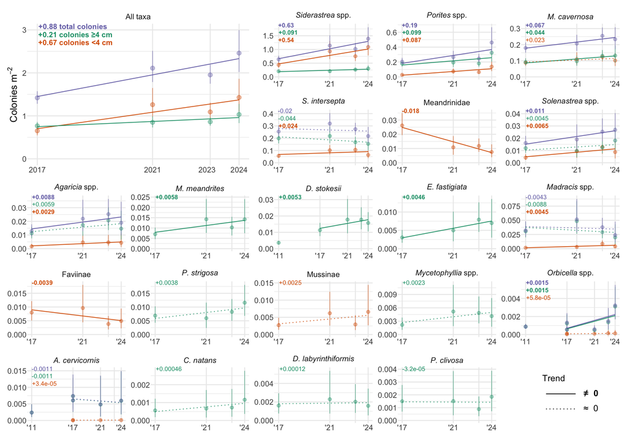

```r
# Final Figure 5 trends plot

alltax <- ggplot(summary_datasets %>% filter(taxon == "All"), aes(x = year, y = mean_epred)) +
  geom_point(aes(color = class), alpha = 0.4, size = 2) +
  geom_errorbar(aes(color = class, ymin = .lower, ymax = .upper), width = 0, linewidth = 0.2) +
  geom_line(data = preds_combined %>% filter(taxon == "All"), linewidth = 0.4,
            aes(color = class, y = pred_density, linetype = sig_trend)) +
  geom_text(data = trends_summary %>% filter(taxon == "All"),
            aes(x = -Inf, y = Inf,
                label = paste0(ifelse(abs_change > 0,
                        paste0("+", signif(abs_change, 2)),
                        as.character(signif(abs_change, 2))),
                        c(" colonies <4 cm", " colonies ≥4 cm", " total colonies   ")),
                color = class, fontface = ifelse(sig_trend, "bold", "plain")),
            inherit.aes = FALSE, size = 3, hjust = -0.15, vjust = c(4.0, 2.5, 1.0)) +
  facet_wrap(~taxon, scales = "free",
             labeller = labeller(taxon = as_labeller(taxon_labels, label_parsed))) +
  labs(y = expression("Colonies m"^-2)) +
  scale_y_continuous(limits = c(0, NA)) +
  scale_linetype_manual(values = c(`FALSE` = 3, `TRUE` = 1)) +
  scale_color_manual(values = c('#d95f02', '#1b9e77', '#7570b3')) +
  scale_x_continuous(breaks = c(11, 17, 21, 23, 24),
                     labels = c(
                       str_pad("2011", width = 4, side = "right"),
                       str_pad("2017", width = 4, side = "right"),
                       str_pad("2021", width = 4, side = "right"),
                       str_pad("2023", width = 7, side = "right"),
                       str_pad("2024", width = 4, side = "left")))+
  theme_minimal(base_size = 11) +
  theme(plot.background = element_rect(fill = "white", color = NA),
        axis.title.x = element_blank(),
        legend.position = "none",
        panel.grid.minor.x = element_blank(),
        axis.text.y = element_text(margin = margin(r = -2)),
        axis.title.y = element_text(margin = margin(r = -14)),
        axis.text.x = element_text(margin = margin(t = -1)),
        plot.margin = margin(t = 3, r = 3, b = 3, l = 3)) +
  coord_cartesian(clip = "off")

taxa_other <- levels(summary_datasets$taxon)[-1]
p_others <- map(taxa_other, function(taxon) {
  ggplot(summary_datasets %>%
           filter(taxon == !!taxon) %>%
           mutate(class = factor(class, levels = c(">4cm", "<4cm", "All"))),
         aes(x = year, y = mean_epred)) +
  geom_point(aes(color = class), alpha = 0.4) +
  geom_errorbar(aes(color = class, ymin = .lower, ymax = .upper), width = 0, linewidth = 0.2) +
  geom_line(data = preds_combined %>%
           filter(taxon == !!taxon) %>%
           mutate(class = factor(class, levels = c(">4cm", "<4cm", "All"))),
           linewidth = 0.4,
            aes(color = class, y = pred_density, linetype = sig_trend)) +
  geom_text(data = trends_summary %>%
           filter(taxon == !!taxon) %>%
           mutate(class = factor(class, levels = c(">4cm", "<4cm", "All"))),
            aes(x = -Inf, y = y_label,
               label = str_pad(
  ifelse(abs_change > 0,
         paste0("+", signif(abs_change, 2)),
         as.character(signif(abs_change, 2))),
  width = 8,
  side = "right"
),
                color = class, fontface = ifelse(sig_trend, "bold", "plain")),
            inherit.aes = FALSE, size = 2.5, hjust = -0.2, vjust = 0.2) +
  facet_wrap(~taxon, scales = "free",
              labeller = labeller(taxon = as_labeller(taxon_labels, label_parsed))) +
  scale_y_continuous(limits = c(0, NA)) +
  scale_linetype_manual(values = c("FALSE" = 3, "TRUE" = 1), drop = FALSE) +
  scale_color_manual(values = c("<4cm" = "#d95f02", ">4cm" = "#1b9e77", "All" = "#7570b3"),
                     drop = FALSE) +
  scale_x_continuous(breaks = c(11, 17, 21, 23, 24),
                     labels = c(
    str_pad("'11", width = 3, side = "left"),
    str_pad("'17", width = 3, side = "left"),
    str_pad("'21", width = 3, side = "right"), "",
    #str_pad("'23", width = 6, side = "right"),
    str_pad("'24", width = 3, side = "left")))+
  theme_minimal(base_size = 11) +
  theme(plot.background = element_rect(fill = "white", color = NA),
        axis.title.x = element_blank(),
        axis.title.y = element_blank(),
        axis.text.y = element_text(margin = margin(r = -2)),
        axis.text.x = element_text(margin = margin(t = -1)),
        legend.position = "none",
        panel.grid.minor.x = element_blank(),
        plot.margin = margin(t = 3, r = 3, b = 3, l = 3)) +
  coord_cartesian(clip = "off") +
    labs(x = "", y = "")
})


# MAKE STANDALONE LEGEND
# Dummy data for legend creation
legend_data <- data.frame(
  x = 1:2,
  y = 1:2,
  trend = factor(c("credible", "uncertain"), levels = c("credible", "uncertain"))
)

# Build dummy plot for legend
legend_plot <- ggplot(legend_data, aes(x = x, y = y, linetype = trend)) +
  geom_line(linewidth = 0.4) +
  scale_linetype_manual(
    name = "Trend",
    values = c("credible" = "solid", "uncertain" = "dotted"),
    labels = c("<b>≠ 0</b>", "≈ 0"),
  ) +
  theme_void(base_size = 10) +
  theme(
    legend.position = "right",       # vertical legend
    legend.title = element_text(size = 10),
    legend.text = element_text(size = 10),
    theme(legend.key.width = unit(3, "cm"))
  ) +
  guides(linetype = guide_legend(override.aes = list(size = 0.6),
                                 label.theme = element_markdown()),
         color = "none") +
  theme(legend.key.width = unit(1.5, "cm"))

# Extract just the legend
legend_only <- cowplot::get_legend(legend_plot)

# Show legend-only plot
legplot <- cowplot::ggdraw(legend_only)


# Define the layout
layout <- c(
  area(t = 1, l = 1, b = 2, r = 2),  # 'alltax' spans top-left 2×2
  area(t = 1, l = 3, b = 1, r = 3),  # plot 1
  area(t = 1, l = 4, b = 1, r = 4),  # plot 2
  area(t = 1, l = 5, b = 1, r = 5),  # plot 3
  area(t = 2, l = 3, b = 2, r = 3),  # plot 4
  area(t = 2, l = 4, b = 2, r = 4),  # plot 5
  area(t = 2, l = 5, b = 2, r = 5),  # plot 6
  area(t = 3, l = 1, b = 3, r = 1),  # plot 7
  area(t = 3, l = 2, b = 3, r = 2),  # plot 8
  area(t = 3, l = 3, b = 3, r = 3),  # plot 9
  area(t = 3, l = 4, b = 3, r = 4),  # plot 10
  area(t = 3, l = 5, b = 3, r = 5),  # plot 11
  area(t = 4, l = 1, b = 4, r = 1),  # plot 12
  area(t = 4, l = 2, b = 4, r = 2),  # plot 13
  area(t = 4, l = 3, b = 4, r = 3),  # plot 14
  area(t = 4, l = 4, b = 4, r = 4),  # plot 15
  area(t = 4, l = 5, b = 4, r = 5),  # plot 16
  area(t = 5, l = 1, b = 5, r = 1),  # plot 17
  area(t = 5, l = 2, b = 5, r = 2),  # plot 18
  area(t = 5, l = 3, b = 5, r = 3),  # plot 19
  area(t = 5, l = 4, b = 5, r = 4),  # plot 20
  area(t = 5, l = 5, b = 5, r = 5)   # plot 21
)

# Combine plots
final_plot <- alltax + p_others[[1]] + p_others[[2]] + p_others[[3]] +
  p_others[[4]] + p_others[[5]] + p_others[[6]] + p_others[[7]] +
  p_others[[8]] + p_others[[9]] + p_others[[10]] + p_others[[11]] +
  p_others[[12]] + p_others[[13]] + p_others[[14]] + p_others[[15]] +
  p_others[[16]] + p_others[[17]] + p_others[[18]] + p_others[[19]] +
  p_others[[20]] + legplot +
  plot_layout(design = layout)

final_plot
```

```r
save_figure(filename = output_file("Fig4.png"), width = 180, height = 180, units = "mm", dpi = 300)


figz <- (alltax + theme(axis.title.y = element_text(margin = margin(r = 0)))) +
  p_others[[which(taxa_other == "ACER")]] +
  p_others[[which(taxa_other == "ORBI")]] +
  plot_layout(ncol = 3)
save_figure(filename = output_file("Trends_all_acer_orbi.png"), width = 170, height = 70, units = "mm")
```

### 7.2.2 Plot abs. changes

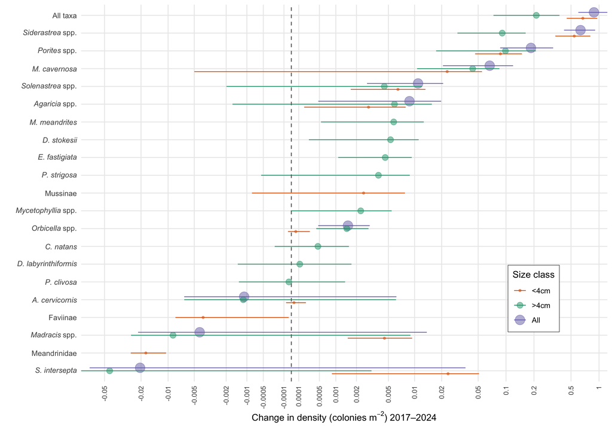

```r
# Final figure 6 trends plot

# Custom signed log-like transform
signed_pseudo_log <- function(x, scale = 1000) {
  sign(x) * log1p(abs(x) * scale)
}

# Transform slopes
scale_factor <- 2000
trends_summary_trans <- trends_summary %>%
  mutate(
    abs_change_trans = signed_pseudo_log(abs_change, scale = scale_factor),
    lower_trans = signed_pseudo_log(abs_change.lower, scale = scale_factor),
    upper_trans = signed_pseudo_log(abs_change.upper, scale = scale_factor),
    taxon = fct_reorder(taxon, abs_change)
  )

# Tick marks (original scale)
ticks <- c(-1, -0.5, -0.2, -0.1, -0.05, -0.02, -0.01, -0.005, -0.002, -0.001,
            -0.0005, -0.0001, 0.0001, 0.0005,
            0.001, 0.002, 0.005, 0.01, 0.02, 0.05, 0.1, 0.2, 0.5, 1)
# Custom function to format tick labels
format_ticks <- function(x) {
  sapply(x, function(v) {
    if (v == 0) {
      "0"
    } else {
      sub("\\.?0+$", "", format(v, scientific = FALSE, trim = TRUE))
    }
  })
}

xmax <- max(trends_summary_trans$upper_trans)
xmin <- min(trends_summary_trans$lower_trans)

# Plot
ggplot(trends_summary_trans, aes(x = abs_change_trans, y = taxon)) +
  geom_point(aes(color = class, size = class), position = position_dodge(width = 0.5),
             alpha = 0.5) +
  geom_errorbarh(aes(color = class, xmin = lower_trans, xmax = upper_trans),
                 position = position_dodge(width = 0.5), height = 0, linewidth = 0.4) +
  geom_vline(xintercept = 0, linetype = "dashed", color = "gray40") +
  scale_x_continuous(
    breaks = signed_pseudo_log(ticks, scale = scale_factor),      # positions in transformed space
    minor_breaks = NULL,
    labels = format_ticks(ticks),       # labels in original space
    limits = c(xmin, xmax),
    expand = expansion(mult = c(0, 0))
  ) +
  scale_y_discrete(
    labels = function(x) parse(text = taxon_labels[x])  # now safe with proper levels
  )  +
  scale_color_manual(values = c("<4cm" = "#d95f02", ">4cm" = "#1b9e77", "All" = "#7570b3"))+
  scale_size_manual(values = c(1,3,5)) +
  labs(
    x = expression("Change in density (colonies m"^{-2}*") 2017–2024"),
    y = "",
    color = "Size class",
    size = "Size class"
  ) +
  theme_minimal() +
  coord_cartesian(clip = "off") +
  theme(axis.text.x = element_text(angle = 90, vjust = 0.5, hjust = 1, size = 8),
        plot.background = element_rect(fill = "white", color = NA),
        legend.position = c(0.86, 0.22),
        legend.background = element_rect(fill = "white", linewidth = 0.2),
        legend.spacing.y = unit(0.1, "cm"),    # vertical space between items
        legend.spacing.x = unit(0.1, "cm"))    # horizontal space between items)
```

```r
save_figure(filename = output_file("Fig5.png"), width = 140, height = 120, units = "mm", dpi = 300)
```

```r
# Fixed manuscript color identity, independent of the new fitted abundance ranking.
taxon_palette_order <- c("SIDE", "PORI", "SINT", "MCAV", "MADR", "AGAR", "SOLE", "MMEA", "DSTO", "ACER", "MEAN", "PSTR", "EFAS", "MYCE", "FAVI", "MUSS", "PCLI", "DLAB", "ORBI", "CNAT")
```

## 7.3 Totals in impact zones

### 7.3.1 Equal-weighted estimates

```r
format_count <- function(x) {
  format(round(x), big.mark = ",", scientific = FALSE, trim = TRUE)
}

format_interval_count <- function(estimate, lower, upper) {
  paste0(
    format_count(estimate),
    " (",
    format_count(lower),
    "-",
    format_count(upper),
    ")"
  )
}

make_taxclass_zone_interval_table <- function(draw_totals) {
  draw_totals <- draw_totals %>%
    mutate(
      taxon = as.character(taxon),
      class = as.character(class),
      name = as.character(name)
    )

  draw_totals_for_table <- bind_rows(
    draw_totals,
    draw_totals %>%
      group_by(.draw, taxon, class) %>%
      summarize(name = "Total", tot = sum(tot), .groups = "drop"),
    draw_totals %>%
      group_by(.draw, name) %>%
      summarize(taxon = "Total", class = "-", tot = sum(tot), .groups = "drop"),
    draw_totals %>%
      group_by(.draw) %>%
      summarize(taxon = "Total", class = "-", name = "Total", tot = sum(tot), .groups = "drop")
  )

  draw_totals_for_table %>%
    mutate(
      name = factor(name, levels = c(zone_levels, "Total")),
      taxon = factor(taxon, levels = c(sort(unique(draw_totals$taxon)), "Total")),
      class = factor(class, levels = c("<4cm", ">4cm", "-"))
    ) %>%
    group_by(taxon, class, name) %>%
    summarize(
      tot_estimate = mean(tot),
      tot_lower_95 = quantile(tot, 0.025),
      tot_upper_95 = quantile(tot, 0.975),
      .groups = "drop"
    ) %>%
    mutate(tot = format_interval_count(tot_estimate, tot_lower_95, tot_upper_95)) %>%
    arrange(taxon, class, name) %>%
    select(taxon, class, name, tot) %>%
    pivot_wider(names_from = name, values_from = tot, names_sort = FALSE) %>%
    mutate(
      taxon = as.character(taxon),
      class = as.character(class)
    )
}

# TOTAL COLONIES IN EACH IMPACT ZONE
densities_tot_draws <- draws_equal_weighted_combined %>% filter(class != "All")

# Calculate total per taxclass per habitat Type and impact zone
tot1_draws <- left_join(densities_tot_draws, area_summary, by = "Type") %>%
  mutate(tot = n_m2 * total_area_m2)

# Calculate total per taxclass per impact zone (sum all habitat Types)
tot2_draws <- tot1_draws %>%
  group_by(.draw, taxon, class, name) %>%
  summarize(tot = sum(tot), .groups = "drop") %>%
  arrange(name)

tot2 <- tot2_draws %>%
  group_by(taxon, class, name) %>%
  mean_qi(tot, .width = 0.95) %>%
  ungroup() %>%
  mutate(tot = round(tot))

tab2 <- make_taxclass_zone_interval_table(tot2_draws)

tab2 %>%
  knitr::kable(caption = "Total number of colonies in each impact zone - surveys (years) equal-weighted")
```

Total number of colonies in each impact zone - surveys (years) equal-weighted

| taxon | class | Channel | Side Slopes | Depth_10cm | Depth_5cm | Depth_1cm | Depth_0_5cm | Depth_0_1cm | Nearshore | North | East | South | Rest of Monitoring Area | Total |
| --- | --- | --- | --- | --- | --- | --- | --- | --- | --- | --- | --- | --- | --- | --- |
| ACER | <4cm | 3 (0-13) | 4 (1-11) | 11 (3-27) | 11 (3-27) | 51 (14-130) | 34 (10-88) | 89 (25-228) | 12 (3-32) | 2 (0-8) | 1 (0-5) | 1 (0-3) | 303 (85-770) | 521 (147-1,328) |
| ACER | >4cm | 29 (8-107) | 384 (199-697) | 904 (472-1,638) | 926 (482-1,678) | 4,485 (2,330-8,125) | 3,058 (1,588-5,542) | 7,847 (4,095-14,216) | 1,270 (660-2,303) | 9 (0-49) | 5 (0-30) | 4 (0-22) | 25,304 (13,187-45,830) | 44,224 (23,055-80,075) |
| AGAR | <4cm | 436 (208-816) | 53 (22-114) | 223 (109-432) | 223 (110-430) | 988 (477-1,929) | 648 (313-1,256) | 1,734 (827-3,513) | 112 (29-287) | 399 (173-786) | 249 (108-490) | 177 (77-348) | 7,457 (3,743-14,103) | 12,700 (6,410-23,694) |
| AGAR | >4cm | 2,156 (1,381-3,220) | 246 (157-379) | 962 (680-1,357) | 965 (682-1,365) | 4,257 (2,975-6,077) | 2,817 (1,957-4,025) | 7,224 (5,017-10,414) | 482 (242-869) | 1,880 (1,111-2,965) | 1,172 (692-1,848) | 833 (492-1,314) | 32,020 (22,736-44,606) | 55,015 (38,962-76,849) |
| CNAT | >4cm | 72 (23-163) | 11 (4-27) | 45 (18-89) | 44 (18-87) | 199 (79-396) | 130 (51-261) | 353 (139-705) | 24 (4-67) | 60 (14-143) | 37 (9-89) | 26 (6-63) | 1,460 (594-2,830) | 2,463 (1,000-4,703) |
| DLAB | >4cm | 173 (74-323) | 38 (17-72) | 123 (65-213) | 121 (64-209) | 550 (287-965) | 362 (189-635) | 945 (490-1,649) | 75 (25-167) | 100 (33-214) | 63 (20-133) | 44 (14-95) | 3,775 (2,040-6,463) | 6,367 (3,447-10,880) |
| DSTO | >4cm | 500 (331-734) | 452 (299-660) | 1,301 (905-1,808) | 1,301 (902-1,819) | 6,152 (4,249-8,662) | 4,091 (2,815-5,779) | 11,059 (7,644-15,467) | 1,334 (838-2,001) | 316 (180-511) | 197 (112-319) | 140 (80-227) | 38,395 (26,956-52,858) | 65,237 (45,733-90,112) |
| EFAS | >4cm | 471 (278-739) | 63 (36-102) | 279 (175-423) | 265 (168-402) | 1,174 (737-1,792) | 744 (470-1,132) | 2,101 (1,291-3,298) | 49 (11-123) | 259 (120-474) | 162 (75-296) | 115 (53-210) | 8,994 (5,711-13,686) | 14,676 (9,351-22,097) |
| FAVI | <4cm | 460 (270-744) | 189 (113-305) | 542 (344-833) | 538 (340-830) | 2,514 (1,572-3,908) | 1,671 (1,043-2,597) | 4,372 (2,716-6,790) | 472 (248-829) | 227 (107-410) | 141 (67-256) | 101 (47-182) | 16,079 (10,310-24,447) | 27,307 (17,457-41,627) |
| MADR | <4cm | 707 (392-1,156) | 57 (25-123) | 254 (142-431) | 259 (146-439) | 1,122 (621-1,943) | 748 (413-1,305) | 1,887 (1,037-3,314) | 122 (36-309) | 706 (382-1,171) | 440 (238-730) | 313 (169-519) | 8,885 (5,146-14,533) | 15,501 (8,881-25,158) |
| MADR | >4cm | 4,841 (3,227-7,133) | 656 (352-1,221) | 2,217 (1,399-3,555) | 2,245 (1,416-3,611) | 10,009 (6,210-16,531) | 6,716 (4,152-11,131) | 16,573 (10,143-28,049) | 1,439 (557-3,200) | 4,151 (2,632-6,369) | 2,587 (1,640-3,969) | 1,840 (1,166-2,823) | 72,088 (46,789-111,677) | 125,361 (81,116-194,600) |
| MCAV | <4cm | 10,613 (7,746-14,178) | 1,762 (1,298-2,390) | 6,620 (5,195-8,287) | 6,540 (5,125-8,219) | 29,414 (22,885-37,288) | 19,252 (14,925-24,581) | 51,663 (39,880-65,707) | 3,595 (2,231-5,537) | 8,321 (5,504-11,847) | 5,186 (3,430-7,383) | 3,688 (2,439-5,250) | 212,882 (167,940-265,349) | 359,535 (283,862-448,514) |
| MCAV | >4cm | 11,915 (8,913-15,729) | 1,694 (1,291-2,190) | 6,374 (5,137-7,857) | 6,263 (5,039-7,719) | 27,935 (22,411-34,564) | 18,259 (14,644-22,643) | 48,108 (38,225-60,061) | 2,817 (1,819-4,238) | 8,577 (5,877-12,188) | 5,345 (3,663-7,596) | 3,801 (2,605-5,402) | 205,537 (165,620-252,534) | 346,625 (278,922-426,500) |
| MEAN | <4cm | 1,265 (876-1,777) | 366 (249-523) | 1,124 (823-1,518) | 1,121 (817-1,522) | 5,175 (3,739-7,096) | 3,440 (2,472-4,738) | 8,997 (6,488-12,314) | 913 (553-1,417) | 895 (560-1,372) | 558 (349-855) | 397 (248-608) | 34,363 (25,605-45,760) | 58,616 (43,522-78,187) |
| MMEA | >4cm | 1,424 (953-2,055) | 182 (118-274) | 588 (417-818) | 576 (408-803) | 2,551 (1,797-3,581) | 1,689 (1,187-2,385) | 4,060 (2,842-5,680) | 214 (101-399) | 843 (494-1,332) | 525 (308-830) | 374 (219-590) | 18,557 (13,184-25,724) | 31,584 (22,396-43,859) |
| MUSS | <4cm | 532 (284-891) | 88 (36-192) | 300 (158-565) | 303 (159-576) | 1,365 (696-2,688) | 911 (460-1,805) | 2,328 (1,165-4,607) | 214 (58-554) | 469 (231-831) | 293 (144-518) | 208 (102-368) | 9,639 (5,232-17,326) | 16,649 (9,045-29,916) |
| MYCE | >4cm | 445 (251-738) | 58 (32-99) | 198 (119-313) | 190 (114-300) | 841 (500-1,336) | 548 (325-870) | 1,367 (796-2,191) | 44 (9-116) | 215 (92-416) | 134 (57-260) | 95 (41-185) | 6,200 (3,752-9,708) | 10,337 (6,244-16,132) |
| ORBI | <4cm | 11 (2-34) | 2 (0-8) | 7 (1-21) | 7 (1-20) | 30 (7-93) | 20 (4-62) | 49 (11-157) | 4 (1-15) | 6 (1-19) | 4 (0-12) | 3 (0-9) | 200 (45-626) | 341 (79-1,056) |
| ORBI | >4cm | 92 (56-145) | 14 (9-21) | 66 (45-95) | 65 (44-92) | 289 (197-413) | 185 (126-265) | 533 (360-776) | 28 (15-47) | 78 (44-129) | 49 (27-81) | 34 (19-57) | 2,177 (1,495-3,141) | 3,610 (2,490-5,153) |
| PCLI | >4cm | 31 (7-83) | 87 (41-161) | 210 (102-387) | 214 (104-395) | 1,029 (499-1,907) | 699 (338-1,297) | 1,799 (872-3,331) | 277 (130-523) | 12 (1-47) | 8 (0-29) | 5 (0-21) | 5,910 (2,887-10,883) | 10,280 (5,024-18,969) |
| PORI | <4cm | 8,782 (5,890-12,461) | 1,237 (846-1,765) | 4,368 (3,225-5,849) | 4,449 (3,272-5,971) | 19,899 (14,554-26,894) | 13,339 (9,731-18,044) | 33,754 (24,622-45,671) | 3,118 (1,911-4,805) | 8,381 (5,308-12,340) | 5,223 (3,308-7,690) | 3,714 (2,352-5,469) | 143,479 (106,544-190,878) | 249,745 (185,027-332,600) |
| PORI | >4cm | 28,035 (19,964-38,316) | 2,957 (2,228-3,926) | 11,737 (9,206-14,768) | 11,801 (9,243-14,912) | 51,828 (40,509-65,781) | 34,353 (26,839-43,735) | 87,350 (68,290-111,029) | 5,665 (3,609-8,571) | 24,812 (16,507-35,635) | 15,463 (10,287-22,208) | 10,996 (7,316-15,793) | 394,065 (307,589-498,260) | 679,062 (529,765-860,870) |
| PSTR | >4cm | 383 (217-606) | 196 (126-295) | 618 (422-878) | 606 (412-865) | 2,828 (1,917-4,078) | 1,852 (1,251-2,676) | 5,102 (3,450-7,310) | 481 (268-808) | 150 (62-289) | 94 (39-180) | 67 (28-128) | 18,504 (12,723-25,963) | 30,882 (21,150-43,634) |
| SIDE | <4cm | 44,866 (32,271-60,901) | 28,950 (19,764-41,575) | 80,143 (57,605-110,390) | 80,756 (57,674-111,574) | 381,164 (270,754-530,403) | 255,561 (180,769-357,247) | 671,935 (477,696-935,503) | 85,526 (55,474-125,995) | 32,907 (21,011-48,127) | 20,508 (13,094-29,993) | 14,584 (9,312-21,329) | 2,365,480 (1,723,179-3,215,815) | 4,062,381 (2,947,267-5,537,886) |
| SIDE | >4cm | 20,013 (15,080-26,142) | 4,392 (3,314-5,783) | 15,572 (12,510-19,317) | 15,284 (12,224-18,946) | 69,551 (55,320-86,791) | 45,413 (36,008-56,736) | 123,217 (97,555-154,813) | 9,144 (6,023-13,300) | 13,515 (9,109-19,483) | 8,422 (5,677-12,142) | 5,990 (4,037-8,634) | 488,281 (393,944-600,047) | 818,794 (658,821-1,007,111) |
| SINT | <4cm | 9,815 (6,989-13,639) | 1,650 (1,182-2,283) | 5,597 (4,283-7,284) | 5,605 (4,267-7,320) | 25,268 (19,111-33,301) | 16,793 (12,646-22,193) | 43,085 (32,513-57,037) | 3,672 (2,280-5,619) | 7,955 (5,180-11,763) | 4,957 (3,228-7,330) | 3,525 (2,296-5,213) | 178,658 (136,849-230,627) | 306,581 (234,490-396,731) |
| SINT | >4cm | 19,324 (14,366-25,717) | 3,659 (2,702-4,907) | 12,221 (9,602-15,328) | 12,111 (9,509-15,261) | 54,872 (42,838-69,685) | 36,251 (28,192-46,282) | 94,156 (73,190-119,723) | 7,594 (4,847-11,460) | 13,716 (9,287-19,681) | 8,548 (5,788-12,265) | 6,079 (4,116-8,722) | 383,836 (303,493-478,308) | 652,366 (515,985-817,097) |
| SOLE | <4cm | 659 (360-1,134) | 189 (104-329) | 670 (412-1,062) | 668 (409-1,058) | 3,068 (1,874-4,919) | 2,015 (1,231-3,250) | 5,560 (3,366-8,937) | 514 (248-959) | 609 (301-1,087) | 379 (188-677) | 270 (134-482) | 21,111 (13,240-32,931) | 35,713 (22,352-55,692) |
| SOLE | >4cm | 525 (323-805) | 462 (301-693) | 1,297 (889-1,867) | 1,299 (887-1,873) | 6,153 (4,181-8,921) | 4,105 (2,773-5,988) | 10,980 (7,473-15,851) | 1,364 (843-2,112) | 321 (164-556) | 200 (102-346) | 142 (73-246) | 38,080 (26,329-54,350) | 64,930 (44,732-92,620) |
| Total | - | 168,581 (149,308-190,655) | 50,100 (40,341-62,856) | 154,569 (130,713-185,516) | 154,756 (130,582-186,224) | 714,760 (597,925-866,970) | 475,705 (396,545-577,544) | 1,248,228 (1,041,800-1,515,503) | 130,576 (99,232-171,887) | 129,892 (111,967-151,285) | 80,948 (69,777-94,281) | 57,566 (49,622-67,047) | 4,741,722 (4,055,536-5,624,949) | 8,107,403 (6,929,606-9,657,672) |

```r
write_csv(tab2, file = output_file("TableA4.csv"))


# Calculate total ESA and non-ESA corals per impact zone
tot3_draws <- tot2_draws %>%
  mutate(ESA = case_when(!taxon %in% c("ACER", "ORBI") ~ "non-ESA",
                         TRUE ~ taxon)) %>%
  group_by(.draw, name, ESA) %>%
  summarize(tot = sum(tot), .groups = "drop") %>%
  pivot_wider(names_from = ESA, values_from = tot, values_fill = list(tot = 0)) %>%
  mutate(Total = ACER + ORBI + `non-ESA`)

tot3 <- tot3_draws %>%
  group_by(name) %>%
  summarize(
    ACER = round(mean(ACER)),
    ORBI = round(mean(ORBI)),
    `non-ESA` = round(mean(`non-ESA`)),
    Total = round(mean(Total)),
    .groups = "drop"
  ) %>%
  mutate(cum_ACER = cumsum(ACER),
         cum_ORBI = cumsum(ORBI),
         cum_non_ESA = cumsum(`non-ESA`),
         cum_Total = cumsum(Total)) %>%
  mutate(across(where(is.numeric), ~ format(round(.), big.mark = ",")))

tot3 %>%
  knitr::kable(caption = "Total coral colonies in all impact zones")
```

Total coral colonies in all impact zones

| name | ACER | ORBI | non-ESA | Total | cum_ACER | cum_ORBI | cum_non_ESA | cum_Total |
| --- | --- | --- | --- | --- | --- | --- | --- | --- |
| Channel | 32 | 103 | 168,446 | 168,581 | 32 | 103 | 168,446 | 168,581 |
| Side Slopes | 388 | 17 | 49,695 | 50,100 | 420 | 120 | 218,141 | 218,681 |
| Depth_10cm | 915 | 73 | 153,582 | 154,569 | 1,335 | 193 | 371,723 | 373,250 |
| Depth_5cm | 937 | 71 | 153,748 | 154,756 | 2,272 | 264 | 525,471 | 528,006 |
| Depth_1cm | 4,535 | 319 | 709,907 | 714,760 | 6,807 | 583 | 1,235,378 | 1,242,766 |
| Depth_0_5cm | 3,092 | 205 | 472,408 | 475,705 | 9,899 | 788 | 1,707,786 | 1,718,471 |
| Depth_0_1cm | 7,937 | 582 | 1,239,709 | 1,248,228 | 17,836 | 1,370 | 2,947,495 | 2,966,699 |
| Nearshore | 1,283 | 32 | 129,261 | 130,576 | 19,119 | 1,402 | 3,076,756 | 3,097,275 |
| North | 10 | 84 | 129,797 | 129,892 | 19,129 | 1,486 | 3,206,553 | 3,227,167 |
| East | 7 | 52 | 80,890 | 80,948 | 19,136 | 1,538 | 3,287,443 | 3,308,115 |
| South | 5 | 37 | 57,524 | 57,566 | 19,141 | 1,575 | 3,344,967 | 3,365,681 |
| Rest of Monitoring Area | 25,607 | 2,377 | 4,713,739 | 4,741,722 | 44,748 | 3,952 | 8,058,706 | 8,107,403 |

```r
dir.create(output_file("intermediate"), recursive = TRUE, showWarnings = FALSE)
write_csv(tot3, file = output_file("intermediate/coral_Table2.csv"))

tot3_total_draws <- tot3_draws %>%
  group_by(.draw) %>%
  summarize(
    name = "Total",
    ACER = sum(ACER),
    ORBI = sum(ORBI),
    `non-ESA` = sum(`non-ESA`),
    Total = sum(Total),
    .groups = "drop"
  )

tot3_intervals <- bind_rows(tot3_draws, tot3_total_draws) %>%
  mutate(name = factor(name, levels = c(zone_levels, "Total"))) %>%
  arrange(name) %>%
  group_by(name) %>%
  summarize(
    ACER_estimate = mean(ACER),
    ACER_lower_95 = quantile(ACER, 0.025),
    ACER_upper_95 = quantile(ACER, 0.975),
    ORBI_estimate = mean(ORBI),
    ORBI_lower_95 = quantile(ORBI, 0.025),
    ORBI_upper_95 = quantile(ORBI, 0.975),
    non_ESA_estimate = mean(`non-ESA`),
    `non-ESA_lower_95` = quantile(`non-ESA`, 0.025),
    `non-ESA_upper_95` = quantile(`non-ESA`, 0.975),
    Total_estimate = mean(Total),
    Total_lower_95 = quantile(Total, 0.025),
    Total_upper_95 = quantile(Total, 0.975),
    .groups = "drop"
  ) %>%
  rename(
    ACER = ACER_estimate,
    ORBI = ORBI_estimate,
    `non-ESA` = non_ESA_estimate,
    Total = Total_estimate
  ) %>%
  select(
    name,
    ACER, ACER_lower_95, ACER_upper_95,
    ORBI, ORBI_lower_95, ORBI_upper_95,
    `non-ESA`, `non-ESA_lower_95`, `non-ESA_upper_95`,
    Total, Total_lower_95, Total_upper_95
  ) %>%
  mutate(name = as.character(name))

tot3_intervals %>%
  knitr::kable(caption = "Total coral colonies in all impact zones with 95% posterior intervals")
```

Total coral colonies in all impact zones with 95% posterior intervals

| name | ACER | ACER_lower_95 | ACER_upper_95 | ORBI | ORBI_lower_95 | ORBI_upper_95 | non-ESA | non-ESA_lower_95 | non-ESA_upper_95 | Total | Total_lower_95 | Total_upper_95 |
| --- | --- | --- | --- | --- | --- | --- | --- | --- | --- | --- | --- | --- |
| Channel | 32.137616 | 9.411098e+00 | 114.08270 | 103.10580 | 63.56960 | 160.91985 | 168445.64 | 149199.92 | 190544.59 | 168580.88 | 149308.46 | 190655.24 |
| Side Slopes | 387.684480 | 2.033113e+02 | 701.01796 | 16.53741 | 10.63625 | 25.50985 | 49695.37 | 39962.66 | 62310.77 | 50099.59 | 40340.96 | 62855.95 |
| Depth_10cm | 914.848279 | 4.842612e+02 | 1650.41964 | 72.75337 | 49.33908 | 106.43753 | 153581.87 | 129796.41 | 184734.17 | 154569.47 | 130712.56 | 185515.98 |
| Depth_5cm | 936.733499 | 4.955366e+02 | 1689.66340 | 71.05371 | 48.52471 | 103.39554 | 153747.80 | 129535.14 | 185296.33 | 154755.59 | 130581.57 | 186223.72 |
| Depth_1cm | 4535.188034 | 2.399060e+03 | 8174.33899 | 318.50288 | 216.48761 | 461.72164 | 709906.70 | 593912.85 | 862268.49 | 714760.39 | 597925.46 | 866970.44 |
| Depth_0_5cm | 3091.884203 | 1.633509e+03 | 5573.58082 | 204.81996 | 139.85013 | 296.73330 | 472407.91 | 393286.12 | 574501.15 | 475704.61 | 396545.20 | 577544.29 |
| Depth_0_1cm | 7936.546515 | 4.203407e+03 | 14312.36772 | 582.34408 | 392.04933 | 850.32599 | 1239709.26 | 1034806.99 | 1509934.93 | 1248228.15 | 1041799.77 | 1515503.45 |
| Nearshore | 1282.580496 | 6.740992e+02 | 2316.50756 | 31.86904 | 17.66291 | 53.69566 | 129261.33 | 97876.15 | 170615.30 | 130575.77 | 99231.67 | 171886.95 |
| North | 10.452358 | 1.003167e+00 | 52.91877 | 83.89015 | 48.32277 | 137.48702 | 129797.49 | 111892.82 | 151169.34 | 129891.83 | 111966.84 | 151285.08 |
| East | 6.513886 | 6.251715e-01 | 32.97886 | 52.28015 | 30.11464 | 85.68160 | 80889.50 | 69731.35 | 94208.40 | 80948.30 | 69777.48 | 94280.52 |
| South | 4.632343 | 4.445900e-01 | 23.45288 | 37.17897 | 21.41599 | 60.93237 | 57524.48 | 49589.37 | 66996.19 | 57566.29 | 49622.18 | 67047.49 |
| Rest of Monitoring Area | 25606.596316 | 1.355360e+04 | 46247.03515 | 2376.80059 | 1620.42579 | 3476.69622 | 4713738.65 | 4031342.87 | 5599267.90 | 4741722.05 | 4055535.98 | 5624949.16 |
| Total | 44745.798025 | 2.368733e+04 | 80827.99567 | 3951.13611 | 2706.39125 | 5762.12402 | 8058705.99 | 6879656.60 | 9602394.01 | 8107402.92 | 6929605.82 | 9657671.98 |

```r
write_csv(tot3_intervals, file = output_file("intermediate/coral_Table2_intervals.csv"))
```

#### 7.3.1.1 Treemap plot - Scenario2+NMFS

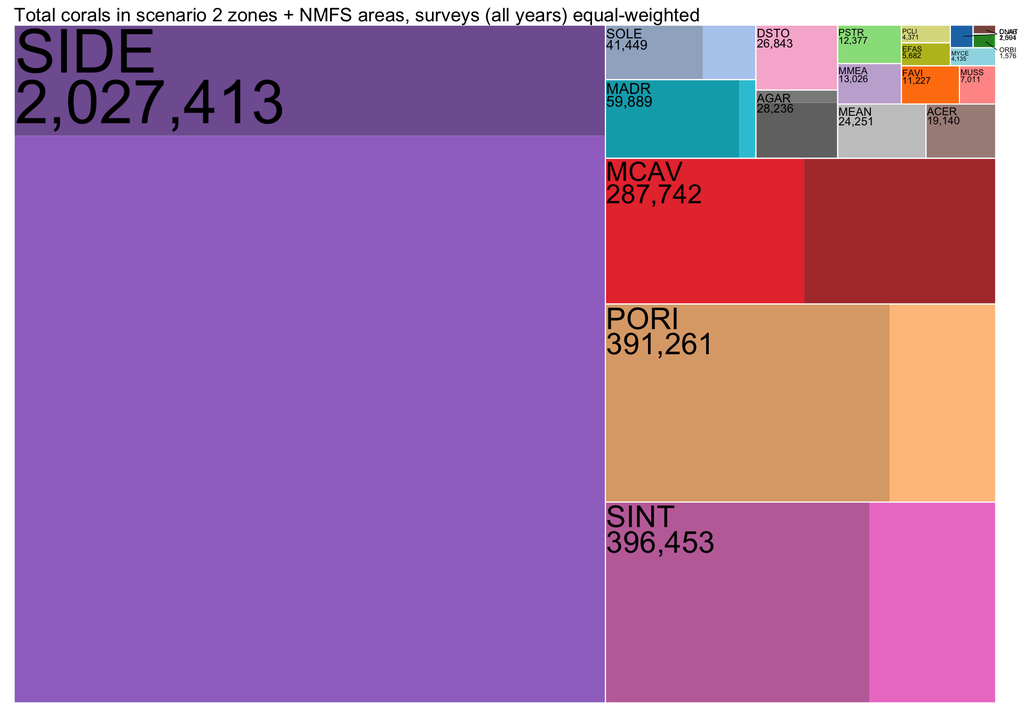

```r
# Aggregate total abundance by taxon + class
tot4 <- tot2 %>%
  filter(name != "Rest of Monitoring Area") %>%
  group_by(taxon, class) %>%
  summarize(tot = sum(tot), .groups = "drop")

# Assign a base color per taxon
set.seed(3)
base_colors <- sample(ggsci::pal_d3("category20")(20), 20)
names(base_colors) <- taxon_palette_order

# Define shading function
get_shades <- function(base_col, class, all_classes) {
  if (length(all_classes) == 2) {
    if (class == "<4cm") colorspace::lighten(base_col, 0.1)
    else colorspace::darken(base_col, 0.1)
  } else {
    base_col
  }
}

# Build taxon_class and corresponding shades
shade_map <- tot4 %>%
  distinct(taxon, class) %>%
  rowwise() %>%
  mutate(
    base_col = base_colors[[taxon]],
    all_classes = list(tot4$class[tot4$taxon == taxon]),
    shade = get_shades(base_col, class, all_classes),
    taxon_class = paste(taxon, class, sep = "_")
  ) %>%
  ungroup()

# Final color map
fill_colors <- setNames(shade_map$shade, shade_map$taxon_class)

# Add taxon_class to original data
tot4 <- tot4 %>%
  mutate(taxon_class = paste(taxon, class, sep = "_"))

# Plot with taxon labels only
p <- ggplot(tot4, aes(area = tot, fill = taxon_class, subgroup = taxon)) +
  geom_treemap(color = NA)+#, layout = "srow") +
  geom_treemap_subgroup_border(colour = "white", size = 1)+#, layout = "srow") +
  # geom_treemap_subgroup_text(place = "topleft", grow = TRUE,
  #                             alpha = 0.8, colour = "black", size = 8) +
  scale_fill_manual(values = fill_colors) +
  theme(legend.position = "none")


# Get tile layout and attach taxon_class
tile_layout <- treemapify(tot4, area = "tot",#, layout = "srow",
                          fill = "taxon_class", subgroup = "taxon")

# Flag small boxes (aggregate size classes)
tile_layout_ag <- tile_layout %>%
  group_by(taxon) %>%
  summarize(xmin = min(xmin), xmax = max(xmax),
            ymin = min(ymin), ymax = max(ymax),
            area = (xmax - xmin) * (ymax - ymin),
            center_x = (xmin + xmax) / 2,
            center_y = (ymin + ymax) / 2)
area_threshold <- 0.001
internal_labels <- tile_layout_ag %>%
  filter(area >= area_threshold)
external_labels <- tile_layout_ag %>%
  filter(area < area_threshold)

# Create labels with taxontotals
taxtots <- tot4 %>%
  group_by(taxon) %>%
  summarize(tot = scales::comma(sum(tot)))

internal_labels <- left_join(internal_labels, taxtots) %>%
  mutate(label = paste0(taxon, "\n", tot))

external_labels <- left_join(external_labels, taxtots) %>%
  mutate(label = paste0(taxon, "\n", tot))

# Final plot
p +
  scale_x_continuous(limits = c(0, 1), expand = c(0, 0)) +
  scale_y_continuous(limits = c(0, 1), expand = c(0, 0)) +
  coord_cartesian(clip = "off") +
  geom_text(data = internal_labels,
            aes(x = xmin, y = ymax-0.00001,
                label = label, size = area), inherit.aes = FALSE,
            hjust = 0, vjust = 1, lineheight = 0.7,
            nudge_x = 0.001, nudge_y = -0.005) +
  scale_size_continuous(range = c(1.5, 15)) +
  geom_text_repel(data = external_labels,
             aes(x = center_x, y = center_y,
                 label = label), inherit.aes = FALSE,
             max.overlaps = Inf,
             box.padding = 0.18,
             xlim = c(1, NA),
             force = 3,
             lineheight = 0.7,
             min.segment.length = 0.1,
             segment.size = 0.2,
             hjust = 0,
             size = 1.7, seed = 123) +
  theme_void() +
  theme(
    legend.position = "none",
    plot.margin = margin(t = 0, r = 20, b = 10, l = 10),
    plot.background = element_rect(fill = "white", color = NA),
  ) +
  labs(title = "Total corals in scenario 2 zones + NMFS areas, surveys (all years) equal-weighted")
```

```r
save_figure(filename = output_file("Fig6.png"), width = 180, height = 130, units = "mm", dpi = 600)
```

#### 7.3.1.2 Treemap plot - Full monitoring area

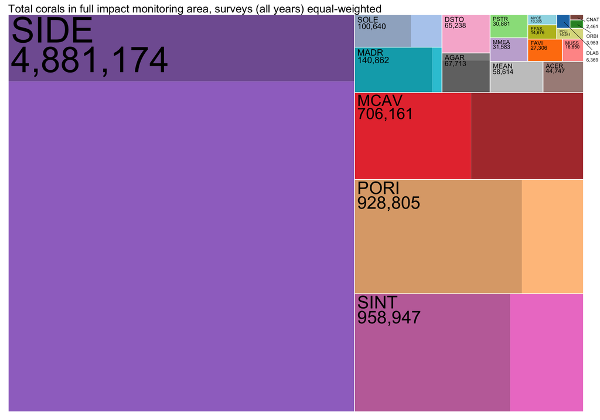

```r
# Aggregate total abundance by taxon + class
tot4 <- tot2 %>%
  group_by(taxon, class) %>%
  summarize(tot = sum(tot), .groups = "drop")

# Assign a base color per taxon
set.seed(3)
base_colors <- sample(ggsci::pal_d3("category20")(20), 20)
names(base_colors) <- taxon_palette_order

# Define shading function
get_shades <- function(base_col, class, all_classes) {
  if (length(all_classes) == 2) {
    if (class == "<4cm") colorspace::lighten(base_col, 0.1)
    else colorspace::darken(base_col, 0.1)
  } else {
    base_col
  }
}

# Build taxon_class and corresponding shades
shade_map <- tot4 %>%
  distinct(taxon, class) %>%
  rowwise() %>%
  mutate(
    base_col = base_colors[[taxon]],
    all_classes = list(tot4$class[tot4$taxon == taxon]),
    shade = get_shades(base_col, class, all_classes),
    taxon_class = paste(taxon, class, sep = "_")
  ) %>%
  ungroup()

# Final color map
fill_colors <- setNames(shade_map$shade, shade_map$taxon_class)

# Add taxon_class to original data
tot4 <- tot4 %>%
  mutate(taxon_class = paste(taxon, class, sep = "_"))

# Plot with taxon labels only
p <- ggplot(tot4, aes(area = tot, fill = taxon_class, subgroup = taxon)) +
  geom_treemap(color = NA) +
  geom_treemap_subgroup_border(colour = "white", size = 1) +
  # geom_treemap_subgroup_text(place = "topleft", grow = TRUE,
  #                             alpha = 0.8, colour = "black", size = 8) +
  scale_fill_manual(values = fill_colors) +
  theme(legend.position = "none")


# Get tile layout and attach taxon_class
tile_layout <- treemapify(tot4, area = "tot",
                          fill = "taxon_class", subgroup = "taxon")

# Flag small boxes (aggregate size classes)
tile_layout_ag <- tile_layout %>%
  group_by(taxon) %>%
  summarize(xmin = min(xmin), xmax = max(xmax),
            ymin = min(ymin), ymax = max(ymax),
            area = (xmax - xmin) * (ymax - ymin),
            center_x = (xmin + xmax) / 2,
            center_y = (ymin + ymax) / 2)
area_threshold <- 0.001
internal_labels <- tile_layout_ag %>%
  filter(area >= area_threshold)
external_labels <- tile_layout_ag %>%
  filter(area < area_threshold)

# Create labels with taxontotals
taxtots <- tot4 %>%
  group_by(taxon) %>%
  summarize(tot = scales::comma(sum(tot)))

internal_labels <- left_join(internal_labels, taxtots) %>%
  mutate(label = paste0(taxon, "\n", tot))

external_labels <- left_join(external_labels, taxtots) %>%
  mutate(label = paste0(taxon, "\n", tot))

# Final plot
p +
  scale_x_continuous(limits = c(0, 1), expand = c(0, 0)) +
  scale_y_continuous(limits = c(0, 1), expand = c(0, 0)) +
  coord_cartesian(clip = "off") +
  geom_text(data = internal_labels,
            aes(x = xmin, y = ymax-0.00001,
                label = label, size = area), inherit.aes = FALSE,
            hjust = 0, vjust = 1, lineheight = 0.7,
            nudge_x = 0.005, nudge_y = -0.005) +
  scale_size_continuous(range = c(1.5, 15)) +
  geom_text_repel(data = external_labels,
             aes(x = center_x, y = center_y,
                 label = label), inherit.aes = FALSE,
             max.overlaps = Inf,
             xlim = c(1, NA),
             force = 5,
             min.segment.length = 0.1,
             segment.size = 0.2,
             hjust = 0, seed = 123,
             size = 2) +
  theme_void() +
  theme(
    legend.position = "none",
    plot.margin = margin(t = 0, r = 20, b = 10, l = 10),
    plot.background = element_rect(fill = "white", color = NA),
  ) +
  labs(title = "Total corals in full impact monitoring area, surveys (all years) equal-weighted")
```

```r
save_figure(filename = output_file("FigA4.png"), width = 180, height = 130, units = "mm", dpi = 600)
```

### 7.3.2 2024 estimates

```r
# TOTAL COLONIES IN EACH IMPACT ZONE
densities_tot_2024_draws <- draws_drm24_combined %>% filter(class != "All")


# Calculate total per taxclass per habitat Type and impact zone
tot1_2024_draws <- left_join(densities_tot_2024_draws, area_summary, by = "Type") %>%
  mutate(tot = n_m2 * total_area_m2)

# Calculate total per taxclass per impact zone (sum all habitat Types)
tot2_2024_draws <- tot1_2024_draws %>%
  group_by(.draw, taxon, class, name) %>%
  summarize(tot = sum(tot), .groups = "drop") %>%
  arrange(name)

tot2_2024 <- tot2_2024_draws %>%
  group_by(taxon, class, name) %>%
  mean_qi(tot, .width = 0.95) %>%
  ungroup() %>%
  mutate(tot = round(tot))

tab2_2024 <- make_taxclass_zone_interval_table(tot2_2024_draws)

tab2_2024 %>%
  knitr::kable(caption = "Total number of colonies in each impact zone - 2024 estimates")
```

Total number of colonies in each impact zone - 2024 estimates

| taxon | class | Channel | Side Slopes | Depth_10cm | Depth_5cm | Depth_1cm | Depth_0_5cm | Depth_0_1cm | Nearshore | North | East | South | Rest of Monitoring Area | Total |
| --- | --- | --- | --- | --- | --- | --- | --- | --- | --- | --- | --- | --- | --- | --- |
| ACER | <4cm | 5 (0-22) | 5 (1-16) | 13 (2-42) | 13 (2-42) | 60 (10-200) | 40 (6-133) | 105 (16-356) | 14 (2-47) | 2 (0-12) | 1 (0-7) | 1 (0-5) | 363 (58-1,207) | 622 (99-2,088) |
| ACER | >4cm | 38 (6-148) | 423 (131-1,040) | 998 (311-2,458) | 1,022 (318-2,519) | 4,946 (1,541-12,203) | 3,372 (1,050-8,323) | 8,655 (2,693-21,343) | 1,396 (434-3,428) | 11 (0-65) | 7 (0-40) | 5 (0-29) | 27,939 (8,708-68,749) | 48,811 (15,228-120,216) |
| AGAR | <4cm | 503 (131-1,430) | 59 (15-160) | 253 (75-664) | 252 (75-653) | 1,116 (327-2,920) | 730 (214-1,893) | 1,960 (569-5,058) | 119 (21-365) | 456 (106-1,374) | 284 (66-856) | 202 (47-609) | 8,477 (2,523-21,362) | 14,412 (4,260-36,841) |
| AGAR | >4cm | 1,860 (751-3,855) | 219 (97-424) | 852 (397-1,605) | 850 (395-1,599) | 3,756 (1,745-7,044) | 2,479 (1,145-4,655) | 6,389 (2,975-11,921) | 409 (154-880) | 1,568 (579-3,430) | 977 (361-2,137) | 695 (257-1,520) | 28,189 (13,057-52,773) | 48,243 (22,277-91,232) |
| CNAT | >4cm | 120 (27-350) | 17 (5-42) | 68 (22-157) | 68 (22-156) | 301 (96-697) | 196 (62-453) | 532 (169-1,236) | 32 (5-96) | 101 (18-326) | 63 (11-203) | 45 (8-144) | 2,247 (717-5,211) | 3,791 (1,196-8,805) |
| DLAB | >4cm | 138 (38-331) | 30 (9-69) | 98 (34-209) | 96 (33-206) | 436 (148-947) | 286 (97-626) | 749 (257-1,617) | 55 (14-142) | 73 (15-206) | 45 (9-128) | 32 (7-91) | 3,007 (1,067-6,401) | 5,046 (1,801-10,775) |
| DSTO | >4cm | 597 (345-975) | 496 (299-768) | 1,472 (941-2,168) | 1,466 (933-2,172) | 6,915 (4,389-10,302) | 4,579 (2,884-6,857) | 12,497 (7,965-18,489) | 1,436 (819-2,313) | 364 (176-703) | 227 (109-438) | 161 (78-311) | 43,685 (28,283-64,034) | 73,895 (47,471-108,323) |
| EFAS | >4cm | 564 (219-1,199) | 75 (30-154) | 339 (148-655) | 321 (140-621) | 1,424 (620-2,755) | 900 (392-1,731) | 2,558 (1,089-5,087) | 54 (10-151) | 302 (92-728) | 188 (57-454) | 134 (41-323) | 10,933 (4,740-21,177) | 17,793 (7,673-34,411) |
| FAVI | <4cm | 333 (131-690) | 128 (57-249) | 373 (169-695) | 368 (167-685) | 1,714 (774-3,198) | 1,134 (512-2,132) | 2,981 (1,333-5,566) | 298 (117-616) | 137 (42-334) | 86 (26-208) | 61 (18-148) | 11,072 (5,028-20,676) | 18,686 (8,463-34,793) |
| MADR | <4cm | 641 (158-1,711) | 52 (12-147) | 232 (63-589) | 237 (64-604) | 1,026 (275-2,628) | 683 (183-1,768) | 1,726 (463-4,412) | 111 (20-333) | 637 (154-1,707) | 397 (96-1,064) | 282 (68-756) | 8,110 (2,225-20,942) | 14,134 (3,861-36,564) |
| MADR | >4cm | 2,684 (976-5,967) | 389 (138-903) | 1,274 (485-2,852) | 1,283 (487-2,848) | 5,739 (2,163-12,962) | 3,844 (1,442-8,674) | 9,474 (3,548-21,515) | 809 (223-2,155) | 2,144 (721-5,084) | 1,336 (449-3,168) | 950 (320-2,253) | 40,885 (15,810-91,996) | 70,811 (27,223-159,433) |
| MCAV | <4cm | 9,534 (5,462-15,204) | 1,610 (1,030-2,434) | 6,127 (4,078-8,972) | 6,021 (3,990-8,849) | 27,086 (17,967-39,829) | 17,653 (11,648-25,940) | 47,801 (31,490-70,096) | 3,113 (1,706-5,223) | 7,108 (3,532-12,570) | 4,430 (2,201-7,834) | 3,150 (1,565-5,571) | 196,479 (130,262-288,415) | 330,112 (217,787-486,297) |
| MCAV | >4cm | 13,786 (8,184-21,693) | 1,930 (1,254-2,852) | 7,363 (4,940-10,605) | 7,206 (4,801-10,415) | 32,103 (21,475-46,305) | 20,919 (14,002-30,224) | 55,377 (37,028-80,152) | 2,993 (1,695-4,983) | 9,604 (4,808-16,753) | 5,985 (2,996-10,441) | 4,257 (2,131-7,425) | 237,335 (157,815-344,152) | 398,859 (264,479-578,640) |
| MEAN | <4cm | 616 (283-1,141) | 180 (86-319) | 553 (277-942) | 548 (274-936) | 2,527 (1,258-4,361) | 1,673 (835-2,906) | 4,393 (2,194-7,561) | 419 (185-779) | 375 (151-767) | 234 (94-478) | 166 (67-340) | 16,810 (8,513-28,602) | 28,494 (14,372-48,493) |
| MMEA | >4cm | 1,781 (881-3,236) | 224 (116-392) | 725 (391-1,221) | 708 (381-1,201) | 3,128 (1,682-5,292) | 2,068 (1,112-3,514) | 4,959 (2,674-8,376) | 238 (96-487) | 1,017 (411-2,080) | 634 (256-1,296) | 451 (182-922) | 22,835 (12,301-38,682) | 38,769 (20,671-66,312) |
| MUSS | <4cm | 849 (283-2,067) | 122 (43-294) | 433 (170-968) | 437 (172-979) | 1,954 (765-4,388) | 1,302 (508-2,941) | 3,324 (1,295-7,526) | 280 (68-774) | 753 (224-1,963) | 469 (140-1,223) | 334 (99-870) | 14,118 (5,648-31,385) | 24,374 (9,718-54,307) |
| MYCE | >4cm | 435 (171-893) | 58 (23-119) | 197 (84-386) | 188 (80-369) | 834 (353-1,642) | 542 (229-1,063) | 1,358 (575-2,747) | 39 (7-113) | 194 (55-479) | 121 (34-299) | 86 (24-213) | 6,139 (2,638-12,134) | 10,194 (4,369-20,091) |
| ORBI | <4cm | 13 (1-51) | 3 (0-11) | 8 (1-31) | 8 (1-30) | 35 (5-139) | 23 (3-92) | 57 (8-232) | 5 (0-19) | 7 (0-28) | 4 (0-17) | 3 (0-12) | 235 (32-932) | 400 (55-1,562) |
| ORBI | >4cm | 282 (132-544) | 34 (18-59) | 171 (94-288) | 167 (93-281) | 741 (411-1,248) | 474 (262-796) | 1,364 (750-2,320) | 60 (27-114) | 249 (106-513) | 155 (66-320) | 110 (47-227) | 5,751 (3,172-9,750) | 9,559 (5,241-16,149) |
| PCLI | >4cm | 44 (8-133) | 108 (40-235) | 263 (97-564) | 268 (99-575) | 1,290 (478-2,769) | 876 (322-1,881) | 2,255 (830-4,850) | 344 (122-759) | 18 (1-73) | 11 (1-46) | 8 (0-32) | 7,435 (2,755-15,875) | 12,921 (4,768-27,666) |
| PORI | <4cm | 20,772 (10,106-38,522) | 2,294 (1,354-3,707) | 8,840 (5,185-14,139) | 9,028 (5,265-14,517) | 39,821 (23,420-63,946) | 26,662 (15,644-42,825) | 67,175 (39,753-107,609) | 5,515 (2,981-9,563) | 20,332 (9,266-38,945) | 12,671 (5,775-24,270) | 9,011 (4,107-17,260) | 298,445 (171,647-484,494) | 520,567 (297,974-848,424) |
| PORI | >4cm | 45,984 (25,470-78,732) | 4,384 (2,836-6,594) | 18,154 (11,688-27,259) | 18,243 (11,656-27,716) | 79,617 (51,009-119,866) | 52,686 (33,641-79,576) | 133,832 (86,023-201,191) | 7,825 (4,407-12,940) | 40,881 (20,190-73,495) | 25,477 (12,582-45,802) | 18,118 (8,948-32,572) | 615,954 (390,313-946,152) | 1,061,156 (665,804-1,640,390) |
| PSTR | >4cm | 568 (268-1,052) | 261 (144-432) | 846 (491-1,328) | 826 (474-1,306) | 3,844 (2,207-6,110) | 2,507 (1,434-3,993) | 6,950 (3,985-10,977) | 615 (297-1,107) | 222 (72-502) | 139 (45-313) | 99 (32-223) | 25,458 (14,861-40,031) | 42,334 (24,516-66,572) |
| SIDE | <4cm | 64,356 (39,919-99,960) | 37,505 (24,011-56,639) | 106,013 (71,416-154,299) | 106,591 (71,372-155,318) | 501,731 (334,852-733,650) | 335,606 (222,434-493,067) | 886,118 (590,924-1,292,651) | 109,040 (66,236-169,935) | 47,069 (24,188-81,560) | 29,333 (15,074-50,828) | 20,860 (10,720-36,146) | 3,146,337 (2,128,041-4,544,586) | 5,390,560 (3,641,110-7,816,959) |
| SIDE | >4cm | 24,606 (15,211-37,177) | 5,160 (3,530-7,340) | 18,756 (13,284-25,886) | 18,337 (12,947-25,379) | 83,240 (58,861-115,648) | 54,149 (38,180-75,194) | 147,863 (103,968-206,548) | 10,150 (6,053-15,873) | 16,110 (8,386-27,931) | 10,040 (5,226-17,406) | 7,140 (3,717-12,379) | 589,827 (417,135-813,157) | 985,378 (694,986-1,358,938) |
| SINT | <4cm | 6,982 (3,650-12,243) | 1,225 (717-1,938) | 4,137 (2,489-6,400) | 4,121 (2,473-6,423) | 18,609 (11,099-28,945) | 12,329 (7,342-19,199) | 31,808 (19,007-49,014) | 2,614 (1,405-4,471) | 5,328 (2,514-10,211) | 3,320 (1,567-6,364) | 2,361 (1,114-4,525) | 131,146 (78,592-204,190) | 223,980 (133,702-349,988) |
| SINT | >4cm | 14,925 (9,061-23,171) | 2,878 (1,870-4,227) | 9,635 (6,451-13,676) | 9,484 (6,320-13,547) | 42,981 (28,604-61,374) | 28,276 (18,749-40,505) | 73,848 (49,192-105,274) | 5,549 (3,213-8,988) | 9,628 (4,754-17,153) | 6,000 (2,962-10,689) | 4,267 (2,107-7,602) | 300,911 (200,557-429,228) | 508,382 (338,303-723,127) |
| SOLE | <4cm | 623 (202-1,446) | 179 (65-390) | 648 (261-1,309) | 644 (259-1,302) | 2,957 (1,185-6,034) | 1,937 (769-3,961) | 5,384 (2,168-11,002) | 481 (155-1,117) | 566 (167-1,365) | 352 (104-851) | 251 (74-605) | 20,437 (8,277-41,208) | 34,459 (13,889-69,802) |
| SOLE | >4cm | 785 (368-1,453) | 607 (322-1,035) | 1,742 (965-2,862) | 1,741 (965-2,869) | 8,221 (4,537-13,559) | 5,470 (3,013-9,062) | 14,705 (8,125-24,229) | 1,760 (907-3,084) | 481 (181-1,028) | 300 (113-641) | 213 (80-456) | 51,438 (28,720-84,680) | 87,462 (48,804-144,351) |
| Total | - | 214,426 (153,527-294,106) | 60,657 (46,171-79,894) | 190,584 (150,784-241,573) | 190,541 (150,070-242,633) | 878,152 (688,663-1,122,906) | 583,396 (455,961-749,004) | 1,536,198 (1,204,454-1,962,468) | 155,773 (110,408-218,128) | 165,738 (102,403-249,483) | 103,287 (63,818-155,477) | 73,453 (45,384-110,567) | 5,871,998 (4,663,587-7,392,495) | 10,024,203 (7,929,223-12,667,346) |

```r
write_csv(tab2_2024, file = output_file("TableA5.csv"))


## SUM ESA and non-ESA corals
# Calculate total ESA and non-ESA corals per impact zone
tot3_2024_draws <- tot2_2024_draws %>%
  mutate(ESA = case_when(!taxon %in% c("ACER", "ORBI") ~ "non-ESA",
                         TRUE ~ taxon)) %>%
  group_by(.draw, name, ESA) %>%
  summarize(tot = sum(tot), .groups = "drop") %>%
  pivot_wider(names_from = ESA, values_from = tot, values_fill = list(tot = 0)) %>%
  mutate(Total = ACER + ORBI + `non-ESA`) %>%
  mutate(name = factor(name, levels = zone_levels)) %>%
  arrange(.draw, name) %>%
  group_by(.draw) %>%
  mutate(cum_ACER = cumsum(ACER),
         cum_ORBI = cumsum(ORBI),
         cum_non_ESA = cumsum(`non-ESA`),
         cum_Total = cumsum(Total)) %>%
  ungroup()

tot3_2024 <- tot3_2024_draws %>%
  select(.draw, name, ACER, ORBI, `non-ESA`, Total, cum_ACER, cum_ORBI, cum_non_ESA, cum_Total) %>%
  pivot_longer(-c(.draw, name), names_to = "metric", values_to = "tot") %>%
  group_by(name, metric) %>%
  summarize(
    tot_estimate = mean(tot),
    tot_lower_95 = quantile(tot, 0.025),
    tot_upper_95 = quantile(tot, 0.975),
    .groups = "drop"
  ) %>%
  mutate(
    name = factor(name, levels = zone_levels),
    metric = factor(metric, levels = c("ACER", "ORBI", "non-ESA", "Total", "cum_ACER", "cum_ORBI", "cum_non_ESA", "cum_Total")),
    tot = format_interval_count(tot_estimate, tot_lower_95, tot_upper_95)
  ) %>%
  arrange(name, metric) %>%
  select(name, metric, tot) %>%
  pivot_wider(names_from = metric, values_from = tot) %>%
  mutate(name = as.character(name))

tot3_2024 %>%
  knitr::kable(caption = "Total coral colonies in all impact zones, 2024 estimates")
```

Total coral colonies in all impact zones, 2024 estimates

| name | ACER | ORBI | non-ESA | Total | cum_ACER | cum_ORBI | cum_non_ESA | cum_Total |
| --- | --- | --- | --- | --- | --- | --- | --- | --- |
| Channel | 43 (8-155) | 296 (140-562) | 214,087 (153,243-293,688) | 214,426 (153,527-294,106) | 43 (8-155) | 296 (140-562) | 214,087 (153,243-293,688) | 214,426 (153,527-294,106) |
| Side Slopes | 427 (137-1,051) | 37 (20-63) | 60,193 (45,764-79,563) | 60,657 (46,171-79,894) | 470 (146-1,170) | 332 (163-615) | 274,280 (207,183-358,143) | 275,083 (207,862-358,989) |
| Depth_10cm | 1,011 (324-2,483) | 179 (99-299) | 189,395 (149,606-240,419) | 190,584 (150,784-241,573) | 1,481 (476-3,665) | 511 (271-894) | 463,675 (364,266-589,341) | 465,667 (366,046-591,011) |
| Depth_5cm | 1,034 (331-2,539) | 175 (97-292) | 189,331 (148,823-241,460) | 190,541 (150,070-242,633) | 2,515 (803-6,238) | 687 (368-1,173) | 653,006 (516,787-825,670) | 656,208 (520,093-828,322) |
| Depth_1cm | 5,006 (1,604-12,288) | 776 (431-1,291) | 872,370 (683,747-1,116,171) | 878,152 (688,663-1,122,906) | 7,521 (2,408-18,500) | 1,463 (806-2,429) | 1,525,376 (1,210,588-1,932,853) | 1,534,360 (1,219,944-1,939,965) |
| Depth_0_5cm | 3,412 (1,094-8,382) | 497 (278-824) | 579,487 (451,853-745,120) | 583,396 (455,961-749,004) | 10,933 (3,504-26,910) | 1,960 (1,087-3,251) | 2,104,863 (1,660,950-2,674,002) | 2,117,756 (1,677,023-2,684,529) |
| Depth_0_1cm | 8,761 (2,807-21,503) | 1,421 (784-2,391) | 1,526,017 (1,196,013-1,955,413) | 1,536,198 (1,204,454-1,962,468) | 19,694 (6,306-48,350) | 3,381 (1,872-5,635) | 3,630,880 (2,857,051-4,630,012) | 3,653,955 (2,882,812-4,653,074) |
| Nearshore | 1,410 (445-3,450) | 64 (30-120) | 154,299 (108,985-216,621) | 155,773 (110,408-218,128) | 21,104 (6,760-51,798) | 3,445 (1,912-5,712) | 3,785,179 (2,966,592-4,842,196) | 3,809,728 (2,992,079-4,859,418) |
| North | 13 (1-72) | 256 (110-519) | 165,469 (102,088-249,133) | 165,738 (102,403-249,483) | 21,117 (6,764-51,805) | 3,701 (2,046-6,166) | 3,950,647 (3,100,813-5,039,564) | 3,975,465 (3,127,155-5,060,154) |
| East | 8 (1-45) | 159 (69-324) | 103,120 (63,621-155,259) | 103,287 (63,818-155,477) | 21,125 (6,767-51,815) | 3,860 (2,124-6,446) | 4,053,767 (3,176,024-5,162,009) | 4,078,753 (3,208,087-5,190,684) |
| South | 6 (0-32) | 113 (49-230) | 73,334 (45,244-110,412) | 73,453 (45,384-110,567) | 21,131 (6,768-51,824) | 3,973 (2,183-6,643) | 4,127,101 (3,227,528-5,259,443) | 4,152,205 (3,266,671-5,285,702) |
| Rest of Monitoring Area | 28,302 (9,066-69,615) | 5,986 (3,286-9,973) | 5,837,710 (4,630,314-7,358,607) | 5,871,998 (4,663,587-7,392,495) | 49,433 (15,847-121,457) | 9,960 (5,466-16,655) | 9,964,811 (7,850,844-12,606,803) | 10,024,203 (7,929,223-12,667,346) |

```r
write_csv(tot3_2024, file = output_file("TableA6.csv"))
```

#### 7.3.2.1 Treemap plot - Scenario2+NMFS

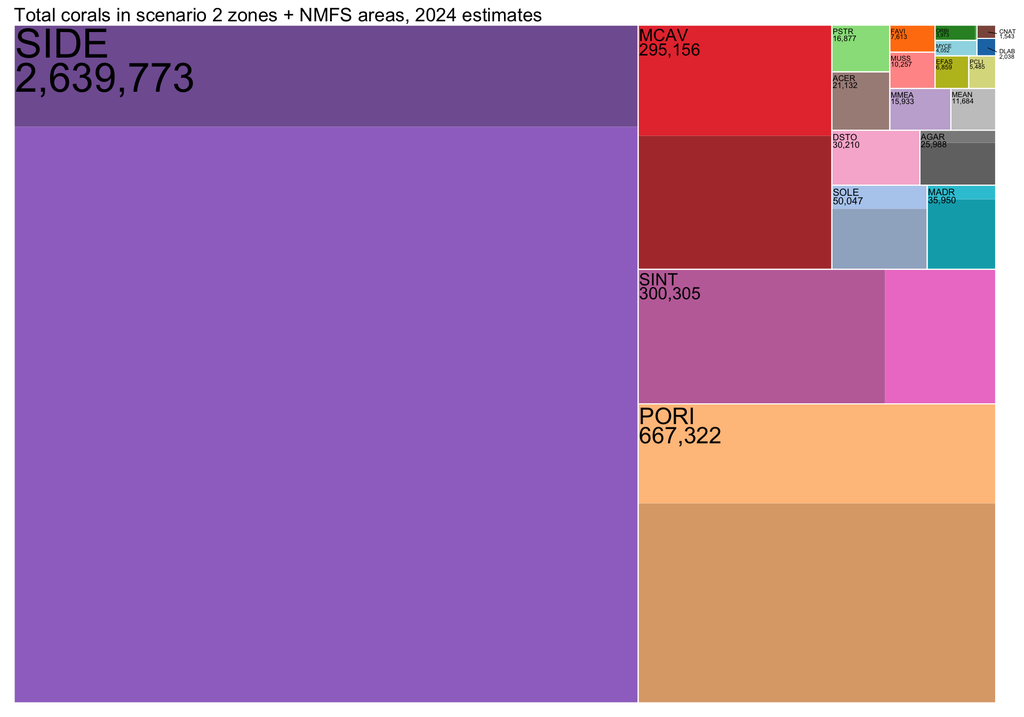

```r
# Aggregate total abundance by taxon + class
tot4_2024 <- tot2_2024 %>%
  filter(name != "Rest of Monitoring Area") %>%
  group_by(taxon, class) %>%
  summarize(tot = sum(tot), .groups = "drop")

# Add taxon_class to original data
tot4_2024 <- tot4_2024 %>%
  mutate(taxon_class = paste(taxon, class, sep = "_"))

# Plot with taxon labels only
p <- ggplot(tot4_2024, aes(area = tot, fill = taxon_class, subgroup = taxon)) +
  geom_treemap(color = NA)+#, layout = "srow") +
  geom_treemap_subgroup_border(colour = "white", size = 1)+#, layout = "srow") +
  # geom_treemap_subgroup_text(place = "topleft", grow = TRUE,
  #                             alpha = 0.8, colour = "black", size = 8) +
  scale_fill_manual(values = fill_colors) +
  theme(legend.position = "none")


# Get tile layout and attach taxon_class
tile_layout <- treemapify(tot4_2024, area = "tot",#, layout = "srow",
                          fill = "taxon_class", subgroup = "taxon")

# Flag small boxes (aggregate size classes)
tile_layout_ag <- tile_layout %>%
  group_by(taxon) %>%
  summarize(xmin = min(xmin), xmax = max(xmax),
            ymin = min(ymin), ymax = max(ymax),
            area = (xmax - xmin) * (ymax - ymin),
            center_x = (xmin + xmax) / 2,
            center_y = (ymin + ymax) / 2)
area_threshold <- 0.0009
internal_labels <- tile_layout_ag %>%
  filter(area >= area_threshold)
external_labels <- tile_layout_ag %>%
  filter(area < area_threshold)

# Create labels with taxontotals
taxtots <- tot4_2024 %>%
  group_by(taxon) %>%
  summarize(tot = scales::comma(sum(tot)))

internal_labels <- left_join(internal_labels, taxtots) %>%
  mutate(label = paste0(taxon, "\n", tot))

external_labels <- left_join(external_labels, taxtots) %>%
  mutate(label = paste0(taxon, "\n", tot))

# Final plot
p +
  scale_x_continuous(limits = c(0, 1), expand = c(0, 0)) +
  scale_y_continuous(limits = c(0, 1), expand = c(0, 0)) +
  coord_cartesian(clip = "off") +
  geom_text(data = internal_labels,
            aes(x = xmin, y = ymax-0.00001,
                label = label, size = area), inherit.aes = FALSE,
            hjust = 0, vjust = 1, lineheight = 0.7,
            nudge_x = 0.001, nudge_y = -0.005) +
  scale_size_continuous(range = c(1.3, 10)) +
  geom_text_repel(data = external_labels,
             aes(x = center_x, y = center_y,
                 label = label), inherit.aes = FALSE,
             max.overlaps = Inf,
             box.padding = 0.18,
             xlim = c(1, NA),
             force = 3,
             lineheight = 0.7,
             min.segment.length = 0.1,
             segment.size = 0.2,
             hjust = 0,
             size = 1.5, seed = 123) +
  theme_void() +
  theme(
    legend.position = "none",
    plot.margin = margin(t = 0, r = 20, b = 10, l = 10),
    plot.background = element_rect(fill = "white", color = NA),
  ) +
  labs(title = "Total corals in scenario 2 zones + NMFS areas, 2024 estimates")
```

```r
save_figure(filename = output_file("FigA5.png"), width = 180, height = 130, units = "mm", dpi = 600)
```

#### 7.3.2.2 Treemap plot - Full monitoring area

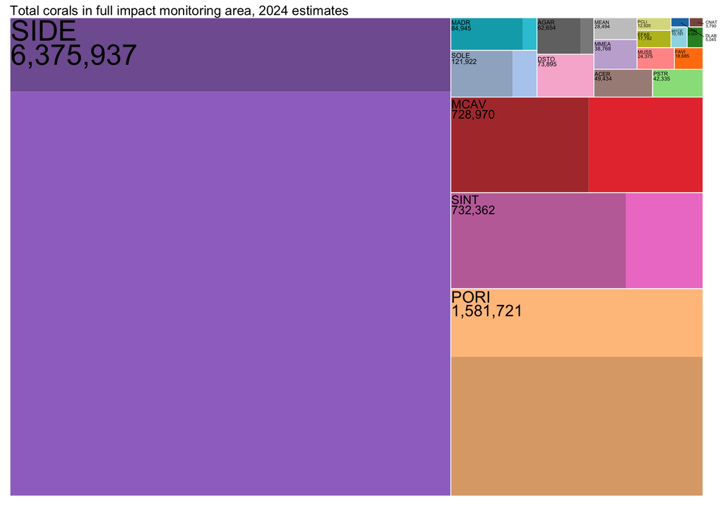

```r
# TOTAL COLONIES IN EACH IMPACT ZONE
densities_tot_2024 <- summary_drm24_combined %>% filter(class != "All")


# Calculate total per taxclass per habitat Type and impact zone
tot1_2024 <- left_join(densities_tot_2024, area_summary, by = "Type") %>%
  mutate(tot = n_m2 * total_area_m2,
         tot_lower = n_m2 * total_area_m2,
         tot_upper = n_m2 * total_area_m2)

# Calculate total per taxclass per impact zone (sum all habitat Types)
tot2_2024 <- tot1_2024 %>%
  group_by(taxon, class, name) %>%
  summarize(tot = round(sum(tot))) %>%
  arrange(name)

# Aggregate total abundance by taxon + class
tot4_2024 <- tot2_2024 %>%
  group_by(taxon, class) %>%
  summarize(tot = sum(tot), .groups = "drop")

# Add taxon_class to original data
tot4_2024 <- tot4_2024 %>%
  mutate(taxon_class = paste(taxon, class, sep = "_"))

# Plot with taxon labels only
p <- ggplot(tot4_2024, aes(area = tot, fill = taxon_class, subgroup = taxon)) +
  geom_treemap(color = NA)+#, layout = "srow") +
  geom_treemap_subgroup_border(colour = "white", size = 1)+#, layout = "srow") +
  # geom_treemap_subgroup_text(place = "topleft", grow = TRUE,
  #                             alpha = 0.8, colour = "black", size = 8) +
  scale_fill_manual(values = fill_colors) +
  theme(legend.position = "none")


# Get tile layout and attach taxon_class
tile_layout <- treemapify(tot4_2024, area = "tot",#, layout = "srow",
                          fill = "taxon_class", subgroup = "taxon")

# Flag small boxes (aggregate size classes)
tile_layout_ag <- tile_layout %>%
  group_by(taxon) %>%
  summarize(xmin = min(xmin), xmax = max(xmax),
            ymin = min(ymin), ymax = max(ymax),
            area = (xmax - xmin) * (ymax - ymin),
            center_x = (xmin + xmax) / 2,
            center_y = (ymin + ymax) / 2)
area_threshold <- 0.0009
internal_labels <- tile_layout_ag %>%
  filter(area >= area_threshold)
external_labels <- tile_layout_ag %>%
  filter(area < area_threshold)

# Create labels with taxontotals
taxtots <- tot4_2024 %>%
  group_by(taxon) %>%
  summarize(tot = scales::comma(sum(tot)))

internal_labels <- left_join(internal_labels, taxtots) %>%
  mutate(label = paste0(taxon, "\n", tot))

external_labels <- left_join(external_labels, taxtots) %>%
  mutate(label = paste0(taxon, "\n", tot))

# Final plot
p +
  scale_x_continuous(limits = c(0, 1), expand = c(0, 0)) +
  scale_y_continuous(limits = c(0, 1), expand = c(0, 0)) +
  coord_cartesian(clip = "off") +
  geom_text(data = internal_labels,
            aes(x = xmin, y = ymax-0.00001,
                label = label, size = area), inherit.aes = FALSE,
            hjust = 0, vjust = 1, lineheight = 0.7,
            nudge_x = 0.001, nudge_y = -0.005) +
  scale_size_continuous(range = c(1.3, 10)) +
  geom_text_repel(data = external_labels,
             aes(x = center_x, y = center_y,
                 label = label), inherit.aes = FALSE,
             max.overlaps = Inf,
             box.padding = 0.18,
             xlim = c(1, NA),
             force = 3,
             lineheight = 0.7,
             min.segment.length = 0.1,
             segment.size = 0.2,
             hjust = 0,
             size = 1.5, seed = 123) +
  theme_void() +
  theme(
    legend.position = "none",
    plot.margin = margin(t = 0, r = 20, b = 10, l = 10),
    plot.background = element_rect(fill = "white", color = NA),
  ) +
  labs(title = "Total corals in full impact monitoring area, 2024 estimates")
```

```r
save_figure(filename = output_file("FigA6.png"), width = 180, height = 130, units = "mm", dpi = 600)


#save_figure(filename = output_file("FigA62.png"), width = 180, height = 90, units = "mm", dpi = 600)
```

# 8 Extra figures

```r
pp3 <- ggplot(polygons_final) +
    geom_sf(aes(fill = Type), color = NA, size = 0.1, alpha = 0.5) +
    geom_point(
        data = selected_original,
        aes(x = longitude, y = latitude),
        pch = 4, alpha = 0.6, size = 1, stroke = 0.4, inherit.aes = FALSE
    ) +
    scale_fill_manual(values = typecols, na.value = "gray80") +
    facet_wrap(~ dataset, ncol = 3,
               labeller = as_labeller(c(
                   "nsu11_esa" = "2011 – NSU ESA Survey",
                   "dca17_esa" = "2017 – DCA ESA Survey",
                   "dca17"     = "2017 – DCA Recon Survey",
                   "tt21"      = "2021 – Tetra Tech Survey",
                   "tt23"      = "2023 – Tetra Tech Survey",
                   "drm24"     = "2024 – Shedd Survey"
               ))) +
    #coord_limits +
    labs(title = NULL, fill = NULL) +
    base_theme +
    theme(
        legend.position = "bottom",
        strip.text = element_text(size = 6),
        panel.spacing = unit(0.5, "lines")
    ) +
  geom_segment(
    data = scale_lines,
    aes(x = x, y = y, xend = xend, yend = yend),
    inherit.aes = FALSE,
    color = "black",
    linewidth = 0.4
  ) +
  geom_segment(
    data = ticks_segments,
    aes(x = x, y = y, xend = xend, yend = yend),
    color = "black",
    linewidth = 0.3
  ) +
  geom_text(
    data = tick_labels,
    aes(x = x, y = y, label = label),
    hjust = 1,
    #vjust = c(rep(1.5, 4), rep(-0.5, 4)),
    size = 1.7
  ) +
  theme(plot.margin = margin(0,0,0,0),
        strip.text = element_text(size = 10, margin = margin(t = 8, b = -8)),
        strip.clip = "off")


save_figure(pp3, filename = output_file("survey_locations.png"), width = 180, height = 220, units = "mm", dpi = 300, bg = "white")
```

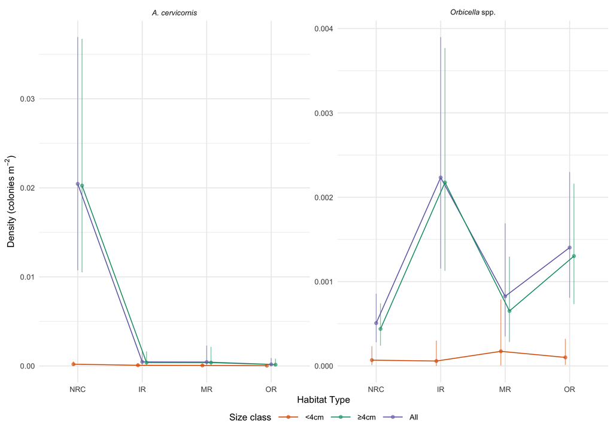

```r
# Create plot for just ACER/ORBI
make_taxon_density_plot(densities = summary_equal_weighted_combined %>%
                          filter(taxon %in% c("ACER", "ORBI")),
                        output_path = output_file("ACERORBI.png"),
                        width = 120, height = 70)
```

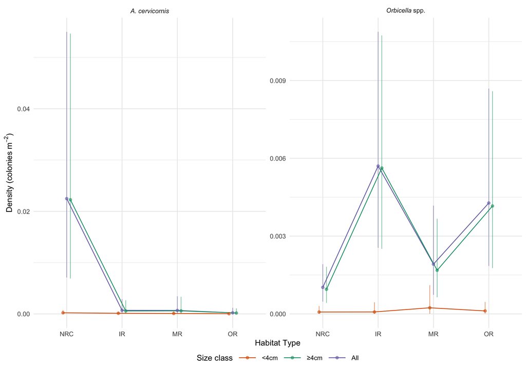

```r
make_taxon_density_plot(densities = summary_drm24_combined %>%
                          filter(taxon %in% c("ACER", "ORBI")),
                        output_path = output_file("ACERORBI_2024.png"),
                        width = 120, height = 70)
```

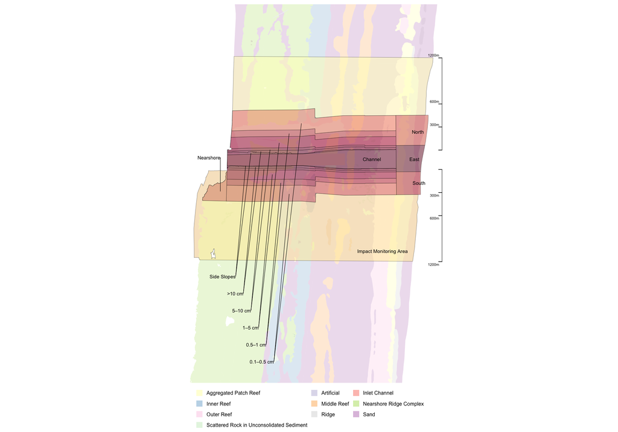

```r
iz_plot_clean2 <- iz_plot_clean +
  coord_sf(xlim = c(-80.1116, -80.077),
           ylim = c(26.0675, 26.112), expand = FALSE) +
  theme(plot.margin = margin(5,5,5,5))

legend_plot <- polyplot +
  scale_fill_manual(values = typecols, na.value = "gray80") +
  guides(
    shape = "none",
    color = "none",
    fill  = guide_legend(nrow = 4, byrow = T)   # <- 3 rows
  ) +
  base_theme +
  theme(
    legend.position = "bottom",
    legend.key.size = unit(0.3, "cm"),
    legend.text = element_text(size = 6),
    legend.title = element_text(size = 7),
    legend.box = "vertical"                         # helps with multi-row at bottom
  )

grob <- ggplotGrob(legend_plot)
fill_legend2 <- gtable::gtable_filter(grob, "guide-box")


zonefig <- plot_grid(iz_plot_clean2, fill_legend2, ncol = 1, rel_heights = c(0.9, 0.1))



zonefig
```

```r
save_figure(zonefig, filename = output_file("zonefig.png"), width = 110, height = 170, units = "mm", bg = "white")
```

# 9 2024 PEV versus the rest of Broward–Miami

The following comparisons use paired predictions from this one joint model, with `dataset = "drm24"`, area 1 m², and direction effects set to zero. Each region’s mean gives NRC, IR, MR and OR equal weight (1/4). The first four Table A3 density columns remain habitat-specific PEV predictions. Its regional columns report habitat-standardized means, their paired difference and posterior sign probabilities. Species sums and adult-plus-juvenile sums retain their within-draw covariance. Own-area weighting is saved separately as a sensitivity comparison, using the footprints defined above. Temporal figures and overall PEV density summaries use the same equal habitat weights. Habitat-specific density and abundance figures retain their existing estimands.

```r
make_regional_table <- function(prepared, fit, output_dir) {
    habitats <- c("Nearshore Ridge Complex", "Inner Reef", "Middle Reef", "Outer Reef")
    juvenile_groups <- c("MCAV", "MEAN", "MUSS", "FAVI")
    nd <- mutate(prepared$grid, dataset = "drm24")
    draw_matrix <- posterior::as_draws_matrix(fit)
    pev <- expected_density_draws(prepared, fit, nd, "PEV")
    regional <- expected_density_draws(prepared, fit, nd, "Broward-Miami")
    stopifnot(all(is.finite(pev)), all(is.finite(regional)), all(table(paste(nd$taxon, nd$class)) ==
        length(habitats)), prepared$datasets[prepared$data$target_dataset] == "drm24")
    prediction_checks <- read_csv(file.path(output_dir, "prediction_validation.csv"), show_col_types = FALSE)
    brms_prediction_checks_pass <- all(prediction_checks$pass)
    tc <- mutate(distinct(prepared$grid, taxon, class), row_type = "Taxon")
    combined <- transmute(filter(count(tc, taxon), n > 1), taxon, class = "All", row_type = "Taxon")
    rows <- arrange(bind_rows(tc, combined), taxon, match(class, c("<4cm", ">4cm", "All")))
    rows <- bind_rows(rows, data.frame(taxon = "Total modeled taxa", class = c("<4cm", ">4cm", "All"),
        row_type = "Total"), data.frame(taxon = "Surveyed juvenile groups (4)", class = "<4cm",
        row_type = "Surveyed juvenile subtotal"))
    rows$row_id <- seq_len(nrow(rows))
    members <- lapply(seq_len(nrow(rows)), function(i) {
        x <- rows[i, ]
        if (x$row_type == "Taxon")
            which(prepared$tc$taxon == x$taxon & (x$class == "All" | prepared$tc$class == x$class))
        else if (x$row_type == "Total")
            which(x$class == "All" | prepared$tc$class == x$class)
        else which(prepared$tc$class == "<4cm" & prepared$tc$taxon %in% juvenile_groups)
    })
    supported_tc <- prepared$tc$class == ">4cm" | prepared$tc$taxon %in% juvenile_groups
    rows$regional_full_survey_support <- vapply(members, function(ix) all(supported_tc[ix]), logical(1))
    rows$component_count <- lengths(members)
    rows$component_taxa <- vapply(members, function(ix) paste(prepared$tc$taxon[ix], collapse = " + "),
        character(1))
    cell_grid <- mutate(rows[rep(seq_len(nrow(rows)), each = length(habitats)), ], Type = rep(habitats,
        nrow(rows)))
    sum_cells <- function(z) vapply(seq_len(nrow(cell_grid)), function(i) {
        ids <- prepared$tc$tc_id[members[[cell_grid$row_id[i]]]]
        rowSums(z[, prepared$grid$tc_id %in% ids & prepared$grid$Type == cell_grid$Type[i], drop = FALSE])
    }, numeric(nrow(z)))
    a <- sum_cells(pev)
    b <- sum_cells(regional)
    average <- function(z) vapply(rows$row_id, function(i)
        rowMeans(z[, cell_grid$row_id == i, drop = FALSE]), numeric(nrow(z)))
    average_area <- function(z, target_region) vapply(rows$row_id, function(i) {
        cells <- cell_grid$row_id == i
        drop(z[, cells, drop = FALSE] %*% habitat_area_weights(cell_grid$Type[cells], target_region))
    }, numeric(nrow(z)))
    pa <- average(a)
    ra <- average(b)
    pa_area <- average_area(a, "PEV")
    ra_area <- average_area(b, "Broward-Miami")
    difference <- pa - ra
    describe <- function(z, prefix) {
        ans <- as.data.frame(t(apply(z, 2, function(x) c(mean = mean(x), median = median(x), lower = unname(quantile(x,
            0.025)), upper = unname(quantile(x, 0.975))))))
        names(ans) <- paste0(prefix, names(ans))
        ans
    }
    numeric <- bind_cols(rows, describe(pa, "pev_"), describe(ra, "regional_"), describe(difference,
        "difference_"))
    numeric$probability_pev_gt_regional <- colMeans(difference > 0)
    numeric$probability_pev_lt_regional <- colMeans(difference < 0)
    numeric$probability_difference_zero <- colMeans(difference == 0)
    numeric$draws_pev_gt_regional <- colSums(difference > 0)
    numeric$draws_pev_lt_regional <- colSums(difference < 0)
    numeric$support_note <- ifelse(rows$regional_full_survey_support, "", "Juvenile component not surveyed in the added broader Broward-Miami DRM surveys; regional estimate and comparison omitted.")
    numeric$habitat_weighting <- "Equal weights: NRC, IR, MR, OR (primary)"
    area_numeric <- bind_cols(rows, describe(pa_area, "pev_"), describe(ra_area, "regional_"),
      describe(pa_area - ra_area, "difference_")) %>%
      mutate(probability_pev_gt_regional = colMeans(pa_area > ra_area),
             probability_pev_lt_regional = colMeans(pa_area < ra_area),
             probability_difference_zero = colMeans(pa_area == ra_area),
             draws_pev_gt_regional = colSums(pa_area > ra_area),
             draws_pev_lt_regional = colSums(pa_area < ra_area),
             support_note = numeric$support_note,
             habitat_weighting = "Each region's own mapped reef-habitat area proportions (sensitivity)")
    diag_matrix <- cbind(pa[, rows$regional_full_survey_support, drop = FALSE], ra[, rows$regional_full_survey_support,
        drop = FALSE], difference[, rows$regional_full_survey_support, drop = FALSE])
    labels <- paste(rows$taxon[rows$regional_full_survey_support], rows$class[rows$regional_full_survey_support],
        sep = ":")
    colnames(diag_matrix) <- c(paste0(labels, ":PEV"), paste0(labels, ":regional"), paste0(labels,
        ":difference"))
    ar <- array(diag_matrix, dim = c(dim(posterior::as_draws_array(fit))[1:2], ncol(diag_matrix)), dimnames = list(NULL,
        NULL, colnames(diag_matrix)))
    diagnostics <- posterior::summarise_draws(posterior::as_draws_array(ar), "mean", "mcse_mean",
        "rhat", "ess_bulk", "ess_tail")
    # Precision of posterior directional probabilities, retaining chain order.
    # An event observed in every/no draw has no estimable mixing diagnostic;
    # do not interpret a zero estimated MCSE as certainty about its probability.
    event <- 1 * (difference[, rows$regional_full_survey_support, drop = FALSE] < 0)
    event_constant <- apply(event, 2, function(x) all(x == x[1]))
    probability_diagnostics <- data.frame(variable = labels,
      probability_pev_lt_regional = colMeans(event), constant_event = event_constant)
    if (any(!event_constant)) {
      event_array <- array(event[, !event_constant, drop = FALSE],
        dim = c(dim(posterior::as_draws_array(fit))[1:2], sum(!event_constant)),
        dimnames = list(NULL, NULL, labels[!event_constant]))
      event_diagnostics <- posterior::summarise_draws(posterior::as_draws_array(event_array),
        "mcse_mean", "rhat", "ess_bulk", "ess_tail")
      probability_diagnostics <- left_join(probability_diagnostics, event_diagnostics, by = "variable")
    }
    write_csv(probability_diagnostics, file.path(output_dir, "TableA3_probability_diagnostics.csv"))
    unavailable <- !rows$regional_full_survey_support
    for (n in c(paste0("regional_", c("mean", "median", "lower", "upper")), paste0("difference_",
        c("mean", "median", "lower", "upper")), "probability_pev_gt_regional", "probability_pev_lt_regional",
        "probability_difference_zero", "draws_pev_gt_regional", "draws_pev_lt_regional")) {
        numeric[[n]][unavailable] <- NA
        area_numeric[[n]][unavailable] <- NA
    }
    fmt <- function(x, digits = 2) paste0(formatC(mean(x), format = "fg", digits = digits, flag = "#"),
        " [", formatC(quantile(x, 0.025), format = "fg", digits = digits, flag = "#"), "–", formatC(quantile(x,
            0.975), format = "fg", digits = digits, flag = "#"), "]")
    habitat_table <- pivot_wider(select(mutate(cell_grid, estimate = vapply(seq_len(ncol(a)), function(i) fmt(a[,
        i]), character(1))), row_id, Type, estimate), names_from = Type, values_from = estimate)
    formatted <- select(mutate(left_join(select(rows, row_id, taxon, class), habitat_table, by = "row_id"),
        PEV_habitat_averaged = vapply(seq_len(ncol(pa)), function(i) fmt(pa[, i], 3), character(1)),
        Broward_Miami_habitat_averaged = vapply(seq_len(ncol(ra)), function(i) if (unavailable[i])
            ""
        else fmt(ra[, i], 3), character(1)), PEV_minus_Broward_Miami = vapply(seq_len(ncol(difference)),
            function(i) if (unavailable[i])
                ""
            else fmt(difference[, i], 3), character(1)), Pr_PEV_gt_Broward_Miami = ifelse(unavailable,
            "", sprintf("%.4f", numeric$probability_pev_gt_regional)), Pr_PEV_lt_Broward_Miami = ifelse(unavailable,
            "", sprintf("%.4f", numeric$probability_pev_lt_regional)), regional_juvenile_full_DRM_support = rows$regional_full_survey_support,
        support_note = numeric$support_note), -row_id)
    cell_summary <- bind_rows(mutate(bind_cols(cell_grid, describe(a, "")), region = "PEV"), mutate(bind_cols(cell_grid,
        describe(b, "")), region = "Broward-Miami"))
    for (n in c("mean", "median", "lower", "upper")) cell_summary[[n]][cell_summary$region == "Broward-Miami" &
        !cell_summary$regional_full_survey_support] <- NA
    averages <- bind_rows(mutate(rename_with(select(numeric, taxon, class, starts_with("pev_")),
        ~sub("^pev_", "", .x), starts_with("pev_")), region = "PEV"), mutate(rename_with(select(select(numeric,
        taxon, class, starts_with("regional_")), -regional_full_survey_support), ~sub("^regional_",
        "", .x), starts_with("regional_")), region = "Broward-Miami"))
    adult <- prepared$grid$class == ">4cm"
    adult_row <- which(rows$taxon == "Total modeled taxa" & rows$class == ">4cm")
    mcav_all <- which(rows$taxon == "MCAV" & rows$class == "All")
    direct_adult_pev <- rowSums(pev[, adult, drop = FALSE]) / length(habitats)
    direct_adult_regional <- rowSums(regional[, adult, drop = FALSE]) / length(habitats)
    err_sum <- max(abs(pa[, adult_row] - direct_adult_pev),
                   abs(ra[, adult_row] - direct_adult_regional))
    err_diff <- max(abs(difference[, adult_row] - (direct_adult_pev - direct_adult_regional)))
    # Independently verify the arithmetic mean of the four habitat-cell means.
    err_mean <- max(vapply(rows$row_id, function(i) {
      cells <- cell_grid$row_id == i
      max(abs(mean(pa[, i]) - mean(colMeans(a[, cells, drop = FALSE]))),
          abs(mean(ra[, i]) - mean(colMeans(b[, cells, drop = FALSE]))))
    }, numeric(1)))
    eligible <- which(rows$regional_full_survey_support)
    settings <- data.frame(dataset = "drm24", direction_effects = "zero",
        habitat_weighting = "Equal weights: NRC, IR, MR, OR (primary)",
        habitat_weights = "NRC=0.25; IR=0.25; MR=0.25; OR=0.25 in both regions",
        sensitivity_weighting = "Each region's own mapped reef-habitat area proportions",
        sensitivity_pev_area_footprint = "Table A1 project / monitoring zones",
        sensitivity_regional_area_footprint = "Complete map Region=Broward-Miami outside 1,200 m N/S PEV band",
        sensitivity_habitat_area_uncertainty = "Mapped areas treated as fixed",
        posterior_draws = nrow(draw_matrix), adult_taxa = sum(prepared$tc$class == ">4cm"), surveyed_juvenile_groups = length(juvenile_groups),
        reported_comparisons = length(eligible), probability_definition = "Fraction of paired draws with PEV minus Broward-Miami >0 or <0",
        multiplicity_adjustment = "None; posterior summaries only", decision_rule = "None; no significance flags or posterior probability cutoff",
        interval = "Pointwise equal-tailed 95% CrI", status = if (isTRUE(joint_evaluation$diagnostic$pass))
          "Sampling criteria pass; model fit and tail review still required" else
          "Sampling criteria not all passed; comparisons provisional")
    validation <- data.frame(check = c("Adult sum preserves draw-wise covariance", "Adult total contrast equals direct sum of paired cell differences",
        "Every adult taxon is compared", "Only surveyed juvenile groups compared", "MCAV All is compared",
        "Unsupported regional values are blank", "Directional probabilities account for every posterior draw",
        "Both probabilities equal paired posterior sign frequencies", "R predictions match independently checked brms expected densities",
```

```r
        "Primary means equal the arithmetic means of four habitat-cell means", "Each primary habitat weight is exactly one quarter in both regions"),
        pass = c(err_sum < 1e-12, err_diff < 1e-12, all(rows$regional_full_survey_support[rows$class ==
            ">4cm"]), all(rows$taxon[rows$class == "<4cm" & rows$regional_full_survey_support] %in%
            c(juvenile_groups, "Surveyed juvenile groups (4)")), length(mcav_all) == 1 && rows$regional_full_survey_support[mcav_all],
            all(formatted$Broward_Miami_habitat_averaged[unavailable] == "") && all(formatted$PEV_minus_Broward_Miami[unavailable] ==
                "") && all(formatted$Pr_PEV_gt_Broward_Miami[unavailable] == "") && all(formatted$Pr_PEV_lt_Broward_Miami[unavailable] ==
                ""), all(abs(numeric$probability_pev_gt_regional[eligible] + numeric$probability_pev_lt_regional[eligible] +
                numeric$probability_difference_zero[eligible] - 1) < 1e-12), all(numeric$probability_pev_gt_regional[eligible] ==
                numeric$draws_pev_gt_regional[eligible]/nrow(draw_matrix)) && all(numeric$probability_pev_lt_regional[eligible] ==
                numeric$draws_pev_lt_regional[eligible]/nrow(draw_matrix)), brms_prediction_checks_pass,
            err_mean < 1e-12, length(habitats) == 4L &&
              all(vapply(rows$row_id, function(i) sum(cell_grid$row_id == i) == 4L, logical(1)))))
    stopifnot(all(validation$pass), sum(rows$class == ">4cm" & rows$row_type == "Taxon") == 17L)
    write_csv(numeric, file.path(output_dir, "TableA3_regional_comparisons_numeric.csv"), na = "")
    write_csv(area_numeric, file.path(output_dir, "TableA3_own_area_sensitivity_numeric.csv"), na = "")
    write_csv(bind_rows(mutate(numeric, comparison = "Equal habitats (primary)"),
                        mutate(area_numeric, comparison = "Own-area weights (sensitivity)")),
              file.path(output_dir, "regional_weighting_sensitivity.csv"), na = "")
    legacy_contrast <- transmute(left_join(filter(numeric, row_type == "Taxon", class != "All"),
        prepared$tc, by = c("taxon", "class")), taxon, class, tc_id, mean = difference_mean, median = difference_median,
        lower = difference_lower, upper = difference_upper, probability_pev_gt_regional, probability_pev_lt_regional,
        regional_full_survey_support)
    write_csv(legacy_contrast, file.path(output_dir, "habitat_averaged_2024_contrasts.csv"), na = "")
    evaluation_file <- file.path(output_dir, "evaluation.rds")
    if (file.exists(evaluation_file)) {
        evaluation <- readRDS(evaluation_file)
        evaluation$contrast <- legacy_contrast
        evaluation$regional_comparison_method <- settings
        saveRDS(evaluation, evaluation_file)
    }
    write_csv(formatted, file.path(output_dir, "TableA3_extended.csv"), na = "")
    write_csv(formatted, file.path(output_dir, "TableA3.csv"), na = "")
    write_csv(formatted[rows$row_type == "Taxon", c("taxon", "class", habitats)], file.path(output_dir,
        "TableA3_PEV_habitats.csv"), na = "")
    write_csv(averages, file.path(output_dir, "TableA3_habitat_averages_numeric.csv"), na = "")
    write_csv(cell_summary, file.path(output_dir, "TableA3_regional_comparison_cells.csv"), na = "")
    write_csv(settings, file.path(output_dir, "TableA3_comparison_method.csv"))
    write_csv(diagnostics, file.path(output_dir, "TableA3_comparison_diagnostics.csv"))
    write_csv(validation, file.path(output_dir, "TableA3_comparison_validation.csv"))
    writeLines(c("Table A3. PEV and Broward-Miami coral densities predicted for DRM2024.", "Densities and PEV-minus-Broward-Miami differences are colonies/m2: posterior mean [pointwise 95% CrI].",
        "The first four columns are habitat-specific PEV densities. The two regional mean columns average NRC, IR, MR and OR equally (1/4 each) in both regions; direction effects are zero.",
        "The primary comparison standardizes habitat composition between regions; it is not weighted by habitat areas or numbers of surveyed sites.",
        "Own-area results are retained separately in TableA3_own_area_sensitivity_numeric.csv and regional_weighting_sensitivity.csv, not used for the main regional comparison.",
        "For that sensitivity only, PEV weights use unrounded Table A1 project / monitoring-zone areas, and broader Broward-Miami weights use the complete FDEP map region outside the 1,200 m north/south PEV band. These two PEV footprints are not identical; mapped areas are fixed.",
        "Sensitivity habitat areas and proportions are in regional_habitat_area_weights.csv. Artificial is pooled with NRC and Aggregated Patch Reef with OR; other habitat classes are excluded.",
        "All size classes, species sums and contrasts are calculated within each shared posterior draw before summarizing.",
        "The adult total sums 17 modeled adult taxa. The full juvenile and All totals have no regional comparison.",
        "Regional juvenile and All entries are blank where a juvenile component was not surveyed in the added broad DRM surveys.",
        "Only MCAV, MEAN, MUSS and FAVI juveniles have complete added regional coverage; only MCAV has a survey-supported taxon-specific All row.",
        "Surveyed juvenile groups (4) sums those four groups only, not the full juvenile community.",
        "Pr_PEV_gt_Broward_Miami = Pr(PEV minus Broward-Miami >0 | data, model); Pr_PEV_lt_Broward_Miami = Pr(difference <0 | data, model).",
        "Both columns report the observed fraction of paired posterior draws; they are not p-values and have no multiplicity adjustment.",
        "No significance flags or posterior probability decision thresholds are applied. Intervals are pointwise, not simultaneous.",
        sprintf("Probabilities are Monte Carlo estimates from all %d retained draws, displayed to four decimals (draw resolution %.4f).",
            nrow(draw_matrix), 1/nrow(draw_matrix)), "A displayed 0.0000 or 1.0000 means no opposite-sign draw was observed, not certainty about the population difference.",
        "The model fit and reported comparisons retain the documented convergence and sparse-cell tail caveats."),
        file.path(output_dir, "TableA3_notes.txt"))
    manifest_file <- file.path(output_dir, "requested_outputs.csv")
    if (file.exists(manifest_file)) {
        manifest <- read_csv(manifest_file, show_col_types = FALSE)
        new_paths <- file.path(output_dir, c("TableA3.csv", "TableA3_extended.csv", "TableA3_PEV_habitats.csv",
            "TableA3_regional_comparisons_numeric.csv", "TableA3_notes.txt"))
        manifest <- mutate(distinct(bind_rows(select(manifest, path), data.frame(path = new_paths)),
            path), bytes = file.info(path)$size)
        write_csv(manifest, manifest_file)
    }
    list(numeric = numeric, area_numeric = area_numeric, formatted = formatted, cells = cell_summary, settings = settings, diagnostics = diagnostics,
        validation = validation)
}
```

```r
regional_comparison <- make_regional_table(prepared, joint_fit, output_dir)
regional_comparison$formatted %>%
  select(-regional_juvenile_full_DRM_support, -support_note) %>%
  show_table(digits = 4)
```

| taxon | class | Nearshore Ridge Complex | Inner Reef | Middle Reef | Outer Reef | PEV_habitat_averaged | Broward_Miami_habitat_averaged | PEV_minus_Broward_Miami | Pr_PEV_gt_Broward_Miami | Pr_PEV_lt_Broward_Miami |
| --- | --- | --- | --- | --- | --- | --- | --- | --- | --- | --- |
| ACER | <4cm | 0.00022 [0.000035–0.00074] | 0.00013 [0.0000011–0.00047] | 0.000087 [0.00000093–0.00049] | 0.000039 [0.00000057–0.00020] | 0.000118 [0.0000170–0.000385] |  |  |  |  |
| ACER | >4cm | 0.022 [0.0069–0.055] | 0.00058 [0.000052–0.0027] | 0.00060 [0.0000074–0.0033] | 0.00018 [0.0000080–0.0011] | 0.00590 [0.00182–0.0148] | 0.0223 [0.00878–0.0500] | -0.0164 [-0.0439–-0.00131] | 0.0168 | 0.9832 |
| ACER | All | 0.022 [0.0071–0.055] | 0.00070 [0.000079–0.0029] | 0.00069 [0.000021–0.0034] | 0.00022 [0.000017–0.0012] | 0.00602 [0.00191–0.0150] |  |  |  |  |
| AGAR | <4cm | 0.0019 [0.00033–0.0058] | 0.0050 [0.00071–0.018] | 0.0027 [0.00036–0.0094] | 0.0076 [0.0018–0.023] | 0.00431 [0.00130–0.0113] |  |  |  |  |
| AGAR | >4cm | 0.0065 [0.0025–0.014] | 0.012 [0.0047–0.025] | 0.014 [0.0048–0.031] | 0.026 [0.0097–0.057] | 0.0146 [0.00667–0.0277] | 0.0284 [0.0149–0.0505] | -0.0137 [-0.0359–0.00316] | 0.0580 | 0.9420 |
| AGAR | All | 0.0084 [0.0037–0.017] | 0.017 [0.0072–0.036] | 0.016 [0.0066–0.035] | 0.034 [0.014–0.069] | 0.0190 [0.00981–0.0344] |  |  |  |  |
| CNAT | >4cm | 0.00051 [0.000082–0.0015] | 0.0015 [0.00021–0.0049] | 0.00088 [0.000073–0.0034] | 0.0017 [0.00030–0.0055] | 0.00116 [0.000366–0.00277] | 0.00362 [0.00137–0.00767] | -0.00246 [-0.00640–-0.0000804] | 0.0227 | 0.9772 |
| DLAB | >4cm | 0.00088 [0.00022–0.0023] | 0.0019 [0.00040–0.0052] | 0.0024 [0.00046–0.0066] | 0.0012 [0.00025–0.0034] | 0.00158 [0.000551–0.00344] | 0.00180 [0.000529–0.00457] | -0.000223 [-0.00282–0.00178] | 0.4507 | 0.5493 |
| DSTO | >4cm | 0.023 [0.013–0.037] | 0.026 [0.015–0.042] | 0.0080 [0.0039–0.015] | 0.0061 [0.0029–0.012] | 0.0158 [0.0106–0.0224] | 0.0185 [0.0127–0.0270] | -0.00272 [-0.0112–0.00435] | 0.2330 | 0.7670 |
| EFAS | >4cm | 0.00086 [0.00016–0.0024] | 0.013 [0.0044–0.029] | 0.0093 [0.0032–0.021] | 0.0051 [0.0015–0.012] | 0.00698 [0.00302–0.0135] | 0.0148 [0.00668–0.0289] | -0.00784 [-0.0217–0.00172] | 0.0617 | 0.9383 |
| FAVI | <4cm | 0.0047 [0.0019–0.0098] | 0.0059 [0.0021–0.013] | 0.0068 [0.0023–0.016] | 0.0023 [0.00070–0.0056] | 0.00493 [0.00224–0.00943] | 0.00513 [0.00225–0.0114] | -0.000201 [-0.00643–0.00484] | 0.4890 | 0.5110 |
| MADR | <4cm | 0.0018 [0.00032–0.0053] | 0.0018 [0.00018–0.0065] | 0.0018 [0.00014–0.0073] | 0.011 [0.0026–0.029] | 0.00401 [0.00110–0.0103] |  |  |  |  |
| MADR | >4cm | 0.013 [0.0036–0.034] | 0.0071 [0.0020–0.020] | 0.024 [0.0075–0.059] | 0.036 [0.012–0.085] | 0.0199 [0.00783–0.0430] | 0.0116 [0.00329–0.0312] | 0.00827 [-0.0123–0.0305] | 0.8383 | 0.1618 |
| MADR | All | 0.015 [0.0050–0.037] | 0.0090 [0.0029–0.023] | 0.025 [0.0086–0.062] | 0.047 [0.018–0.098] | 0.0239 [0.0109–0.0476] |  |  |  |  |
| MCAV | <4cm | 0.050 [0.027–0.083] | 0.14 [0.082–0.22] | 0.097 [0.054–0.16] | 0.12 [0.059–0.21] | 0.101 [0.0675–0.147] | 0.0802 [0.0536–0.119] | 0.0212 [-0.0289–0.0728] | 0.8067 | 0.1933 |
| MCAV | >4cm | 0.048 [0.027–0.079] | 0.16 [0.091–0.26] | 0.16 [0.092–0.26] | 0.16 [0.080–0.28] | 0.132 [0.0881–0.194] | 0.142 [0.0966–0.206] | -0.00949 [-0.0858–0.0609] | 0.4020 | 0.5980 |
| MCAV | All | 0.097 [0.064–0.14] | 0.30 [0.20–0.42] | 0.26 [0.17–0.37] | 0.28 [0.16–0.45] | 0.234 [0.173–0.308] | 0.222 [0.167–0.293] | 0.0117 [-0.0776–0.101] | 0.6005 | 0.3995 |
| MEAN | <4cm | 0.0067 [0.0030–0.012] | 0.0085 [0.0037–0.017] | 0.0089 [0.0035–0.018] | 0.0063 [0.0025–0.013] | 0.00757 [0.00387–0.0129] | 0.0100 [0.00544–0.0173] | -0.00243 [-0.00999–0.00422] | 0.2422 | 0.7578 |
| MMEA | >4cm | 0.0038 [0.0015–0.0078] | 0.0078 [0.0031–0.016] | 0.028 [0.013–0.054] | 0.017 [0.0069–0.035] | 0.0142 [0.00748–0.0240] | 0.0222 [0.0127–0.0368] | -0.00803 [-0.0238–0.00548] | 0.1190 | 0.8810 |
| MUSS | <4cm | 0.0045 [0.0011–0.012] | 0.0041 [0.00082–0.012] | 0.0051 [0.0011–0.015] | 0.013 [0.0038–0.033] | 0.00658 [0.00267–0.0144] | 0.0147 [0.00573–0.0356] | -0.00815 [-0.0276–0.00238] | 0.0700 | 0.9300 |
| MYCE | >4cm | 0.00063 [0.00012–0.0018] | 0.0041 [0.0011–0.011] | 0.0085 [0.0029–0.019] | 0.0033 [0.00092–0.0080] | 0.00413 [0.00175–0.00818] | 0.00572 [0.00224–0.0118] | -0.00160 [-0.00796–0.00330] | 0.2782 | 0.7218 |
| ORBI | <4cm | 0.000073 [0.0000072–0.00030] | 0.000076 [0.00000043–0.00045] | 0.00024 [0.0000055–0.0011] | 0.00012 [0.0000082–0.00046] | 0.000126 [0.0000143–0.000489] |  |  |  |  |
| ORBI | >4cm | 0.00095 [0.00042–0.0018] | 0.0056 [0.0025–0.011] | 0.0017 [0.00064–0.0037] | 0.0042 [0.0018–0.0086] | 0.00310 [0.00168–0.00529] | 0.0148 [0.00756–0.0255] | -0.0117 [-0.0211–-0.00542] | 0.0000 | 1.0000 |
| ORBI | All | 0.0010 [0.00047–0.0019] | 0.0057 [0.0025–0.011] | 0.0019 [0.00074–0.0042] | 0.0043 [0.0018–0.0087] | 0.00323 [0.00175–0.00551] |  |  |  |  |
| PCLI | >4cm | 0.0055 [0.0020–0.012] | 0.00076 [0.000056–0.0028] | 0.00085 [0.000066–0.0032] | 0.00030 [0.000015–0.0012] | 0.00185 [0.000720–0.00387] | 0.00465 [0.00241–0.00808] | -0.00280 [-0.00644–-0.000116] | 0.0225 | 0.9775 |
| PORI | <4cm | 0.088 [0.048–0.15] | 0.054 [0.026–0.098] | 0.068 [0.033–0.12] | 0.34 [0.16–0.65] | 0.137 [0.0776–0.227] |  |  |  |  |
| PORI | >4cm | 0.12 [0.070–0.21] | 0.21 [0.12–0.35] | 0.28 [0.15–0.47] | 0.68 [0.34–1.2] | 0.325 [0.204–0.500] | 0.389 [0.271–0.545] | -0.0644 [-0.264–0.143] | 0.2500 | 0.7500 |
| PORI | All | 0.21 [0.14–0.31] | 0.27 [0.17–0.41] | 0.34 [0.21–0.54] | 1.0 [0.55–1.7] | 0.462 [0.312–0.667] |  |  |  |  |
| PSTR | >4cm | 0.0098 [0.0047–0.018] | 0.021 [0.011–0.038] | 0.012 [0.0047–0.024] | 0.0037 [0.0012–0.0084] | 0.0116 [0.00679–0.0181] | 0.00818 [0.00461–0.0138] | 0.00340 [-0.00361–0.0104] | 0.8440 | 0.1560 |
| SIDE | <4cm | 1.7 [1.1–2.7] | 1.2 [0.73–1.8] | 0.66 [0.39–1.1] | 0.79 [0.40–1.4] | 1.09 [0.784–1.50] |  |  |  |  |
| SIDE | >4cm | 0.16 [0.096–0.25] | 0.46 [0.29–0.70] | 0.32 [0.19–0.51] | 0.27 [0.14–0.47] | 0.302 [0.214–0.415] | 0.352 [0.249–0.485] | -0.0497 [-0.207–0.106] | 0.2462 | 0.7538 |
| SIDE | All | 1.9 [1.2–2.9] | 1.6 [1.1–2.3] | 0.98 [0.65–1.4] | 1.1 [0.59–1.7] | 1.39 [1.06–1.81] |  |  |  |  |
| SINT | <4cm | 0.042 [0.022–0.071] | 0.055 [0.029–0.094] | 0.068 [0.034–0.12] | 0.089 [0.042–0.17] | 0.0634 [0.0375–0.100] |  |  |  |  |
| SINT | >4cm | 0.088 [0.051–0.14] | 0.17 [0.098–0.26] | 0.20 [0.11–0.33] | 0.16 [0.080–0.29] | 0.154 [0.103–0.219] | 0.251 [0.167–0.361] | -0.0968 [-0.218–0.00701] | 0.0345 | 0.9655 |
| SINT | All | 0.13 [0.086–0.19] | 0.22 [0.15–0.32] | 0.27 [0.17–0.40] | 0.25 [0.14–0.41] | 0.217 [0.157–0.292] |  |  |  |  |
| SOLE | <4cm | 0.0077 [0.0025–0.018] | 0.015 [0.0048–0.034] | 0.0031 [0.00056–0.0090] | 0.0095 [0.0028–0.023] | 0.00872 [0.00352–0.0174] |  |  |  |  |
| SOLE | >4cm | 0.028 [0.014–0.049] | 0.026 [0.012–0.046] | 0.011 [0.0040–0.022] | 0.0080 [0.0030–0.017] | 0.0181 [0.0103–0.0291] | 0.0179 [0.0100–0.0313] | 0.000210 [-0.0139–0.0127] | 0.5270 | 0.4730 |
| SOLE | All | 0.036 [0.020–0.059] | 0.040 [0.022–0.069] | 0.014 [0.0058–0.027] | 0.018 [0.0077–0.035] | 0.0268 [0.0168–0.0405] |  |  |  |  |
| Total modeled taxa | <4cm | 1.9 [1.3–2.9] | 1.5 [1.0–2.1] | 0.92 [0.62–1.3] | 1.4 [0.81–2.2] | 1.43 [1.10–1.86] |  |  |  |  |
| Total modeled taxa | >4cm | 0.54 [0.42–0.68] | 1.1 [0.88–1.4] | 1.1 [0.80–1.4] | 1.4 [0.82–2.2] | 1.03 [0.831–1.28] | 1.31 [1.11–1.55] | -0.276 [-0.569–0.0299] | 0.0403 | 0.9597 |
| Total modeled taxa | All | 2.5 [1.8–3.5] | 2.6 [2.0–3.3] | 2.0 [1.5–2.6] | 2.8 [1.7–4.2] | 2.46 [2.02–2.99] |  |  |  |  |
| Surveyed juvenile groups (4) | <4cm | 0.066 [0.041–0.10] | 0.16 [0.099–0.24] | 0.12 [0.072–0.18] | 0.14 [0.075–0.24] | 0.120 [0.0858–0.167] | 0.110 [0.0784–0.153] | 0.0104 [-0.0433–0.0636] | 0.6538 | 0.3463 |

```r
show_table(regional_comparison$validation)
```

| check | pass |
| --- | --- |
| Adult sum preserves draw-wise covariance | TRUE |
| Adult total contrast equals direct sum of paired cell differences | TRUE |
| Every adult taxon is compared | TRUE |
| Only surveyed juvenile groups compared | TRUE |
| MCAV All is compared | TRUE |
| Unsupported regional values are blank | TRUE |
| Directional probabilities account for every posterior draw | TRUE |
| Both probabilities equal paired posterior sign frequencies | TRUE |
| R predictions match independently checked brms expected densities | TRUE |
| Primary means equal the arithmetic means of four habitat-cell means | TRUE |
| Each primary habitat weight is exactly one quarter in both regions | TRUE |

## 9.1 Regional densities and paired differences

The figure uses the same equal-habitat estimates and paired posterior differences as Table A3. Points are posterior means and intervals are pointwise 95% CrIs. No significance flags or posterior-probability cutoffs are applied. The total includes the 17 modeled adult taxa. This regional-comparison figure is saved separately from the existing numbered PEV manuscript figures. The right-hand column has three stacked sections with linear x-axis limits of +/-0.60, +/-0.10 and +/-0.01 colonies per square metre. Taxa are grouped by the range needed to display their complete 95% CrIs, not by whether a contrast excludes zero. Each row appears once, all intervals are complete, and zero is aligned across sections. The density scale is identical across the left-hand sections, and species rows align between the two columns.

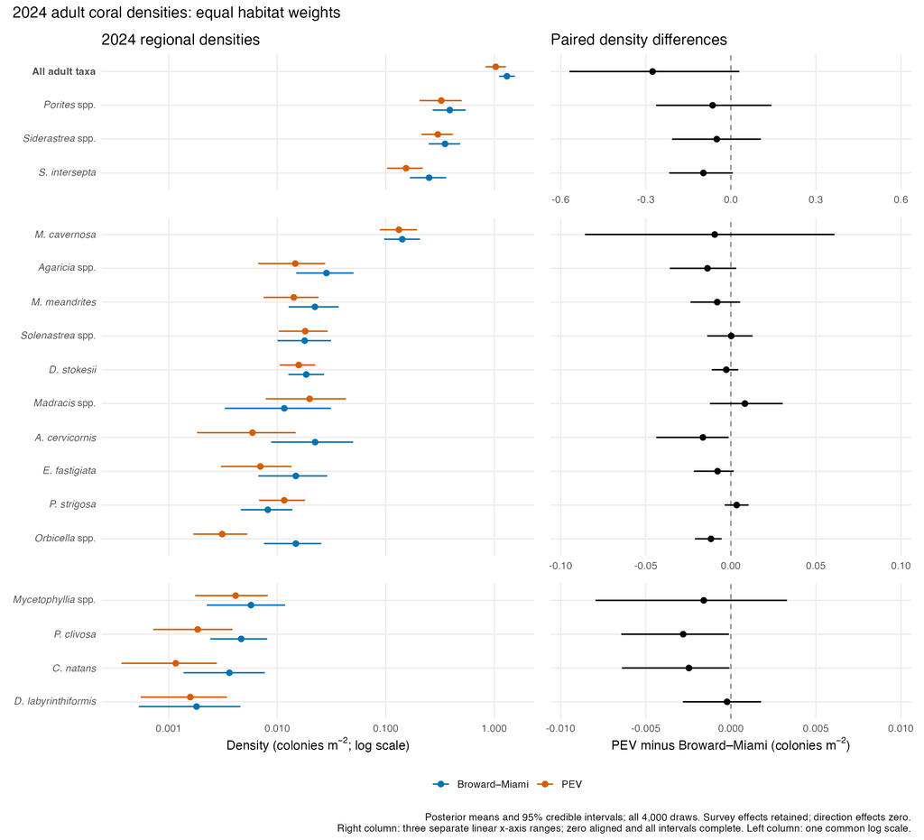

```r
adult_comparison <- regional_comparison$numeric %>%
  filter(class == ">4cm", row_type %in% c("Taxon", "Total")) %>%
  mutate(target = if_else(row_type == "Total", "All adult taxa", as.character(taxon)),
         interval_extent = pmax(abs(difference_lower), abs(difference_upper)),
         section = case_when(interval_extent > 0.10 ~ "larger",
                             interval_extent > 0.01 ~ "intermediate",
                             TRUE ~ "smaller"))
taxon_order <- adult_comparison %>% filter(row_type == "Taxon") %>%
  arrange(desc(pev_mean + regional_mean)) %>% pull(target)
target_levels <- rev(c("All adult taxa", taxon_order))
target_labels <- c(taxon_labels, "All adult taxa" = 'bold("All adult taxa")')
section_specs <- tibble::tibble(
  section = c("larger", "intermediate", "smaller"),
  limit = c(0.60, 0.10, 0.01),
  step = c(0.30, 0.05, 0.005),
  accuracy = c(0.1, 0.01, 0.001)
)
section_counts <- vapply(section_specs$section,
  function(s) sum(adult_comparison$section == s), integer(1))
# Explicit limits must contain every plotted mean and complete interval.
row_limits <- section_specs$limit[match(adult_comparison$section, section_specs$section)]
stopifnot(all(section_counts > 0L),
          all(adult_comparison$interval_extent <= row_limits),
          all(abs(adult_comparison$difference_mean) <= row_limits))
regional_density_plot_data <- bind_rows(
  adult_comparison %>% transmute(target, section, region = "PEV", mean = pev_mean,
                                 lower = pev_lower, upper = pev_upper),
  adult_comparison %>% transmute(target, section, region = "Broward–Miami", mean = regional_mean,
                                 lower = regional_lower, upper = regional_upper)
)
density_x_limits <- range(c(regional_density_plot_data$lower,
                            regional_density_plot_data$upper))
region_colors <- c("PEV" = "#D55E00", "Broward–Miami" = "#0072B2")

make_comparison_section <- function(i) {
  spec <- section_specs[i, ]
  contrasts <- adult_comparison %>% filter(section == spec$section)
  local_levels <- target_levels[target_levels %in% contrasts$target]
  contrasts <- contrasts %>% mutate(y = match(target, local_levels))
  densities <- regional_density_plot_data %>% filter(section == spec$section) %>%
    mutate(y = match(target, local_levels) + if_else(region == "PEV", 0.14, -0.14))
  y_limits <- c(0.5, length(local_levels) + 0.5)
  bottom_section <- i == nrow(section_specs)

  density_panel <- ggplot(densities, aes(y = y, color = region)) +
    geom_segment(aes(x = lower, xend = upper, yend = y), linewidth = .6) +
    geom_point(aes(x = mean), size = 2) +
    scale_x_log10(limits = density_x_limits, breaks = c(0.001, 0.01, 0.1, 1)) +
    scale_y_continuous(breaks = seq_along(local_levels), limits = y_limits,
      expand = expansion(mult = 0),
      labels = function(y) parse(text = target_labels[local_levels[y]])) +
    scale_color_manual(values = region_colors) +
    labs(x = if (bottom_section) expression("Density (colonies " * m^{-2} * "; log scale)"),
         y = NULL, color = NULL,
         title = if (i == 1L) "2024 regional densities") +
    theme_minimal(base_size = 11) +
    theme(panel.grid.minor = element_blank(), legend.position = "bottom")
  if (!bottom_section) {
    density_panel <- density_panel + theme(axis.text.x = element_blank(),
                                           axis.ticks.x = element_blank())
  }

  contrast_panel <- ggplot(contrasts, aes(y = y)) +
    geom_vline(xintercept = 0, linetype = "dashed", color = "gray50") +
    geom_segment(aes(x = difference_lower, xend = difference_upper, yend = y), linewidth = .6) +
    geom_point(aes(x = difference_mean), size = 2) +
    scale_x_continuous(limits = c(-spec$limit, spec$limit),
      breaks = seq(-spec$limit, spec$limit, by = spec$step),
      labels = scales::label_number(accuracy = spec$accuracy), expand = expansion(mult = 0.03)) +
    scale_y_continuous(breaks = seq_along(local_levels), labels = NULL,
      limits = y_limits, expand = expansion(mult = 0)) +
    labs(x = if (bottom_section) expression("PEV minus Broward–Miami (colonies " * m^{-2} * ")"),
         y = NULL, title = if (i == 1L) "Paired density differences") +
    theme_minimal(base_size = 11) +
    theme(panel.grid.minor = element_blank())
  list(density = density_panel, contrast = contrast_panel)
}
section_panels <- lapply(seq_len(nrow(section_specs)), make_comparison_section)
regional_density_figure <- wrap_plots(
  unlist(section_panels, recursive = FALSE), ncol = 2, byrow = TRUE,
  widths = c(1.2, 1), heights = section_counts, guides = "collect"
) +
  plot_annotation(title = "2024 adult coral densities: equal habitat weights",
    caption = paste0("Posterior means and 95% credible intervals; all 4,000 draws. Survey effects retained; direction effects zero.\n",
                     "Right column: three separate linear x-axis ranges; zero aligned and all intervals complete. Left column: one common log scale.")) &
  theme(legend.position = "bottom")
save_figure(output_file("regional_density_comparison.png"), regional_density_figure,
            width = 11, height = 10, dpi = 220, bg = "white")
save_figure(output_file("regional_density_comparison.pdf"), regional_density_figure,
            width = 11, height = 10, device = grDevices::pdf,
            encoding = "WinAnsi.enc", useDingbats = FALSE, bg = "white")
regional_density_figure
```

Define $\Delta=\text{PEV density}-\text{Broward–Miami density}$. The probability columns are the observed fractions of posterior draws with $\Delta>0$ and $\Delta<0$, conditional on the data and model. They are not p-values and are not adjusted. No significance threshold or asterisks are applied. The 95% credible intervals are pointwise, not simultaneous. Probabilities displayed as 0.0000 or 1.0000 mean no opposite-sign draw was observed; they do not establish certainty about the population difference.

The added broad DRM surveys comprehensively count only MCAV, MEAN, MUSS and FAVI juveniles. Regional cells for other juveniles and their “All” rows are blank, while valid PEV estimates remain visible. MCAV “All” is comparable. The full juvenile and adult-plus-juvenile totals have no regional comparison; the separately labeled four-group juvenile subtotal is not the whole juvenile community. The adult total sums the 17 modeled adult taxa.

# 10 Numerical results and reproducibility

```r
write_csv(summary_equal_weighted_combined, output_file("survey_averaged_densities.csv"))
write_csv(summary_drm24_combined, output_file("PEV_2024_densities.csv"))
write_csv(trends_summary, output_file("temporal_trends.csv"))
write_csv(summary_datasets, output_file("temporal_source_densities.csv"))
write_csv(area_summary, output_file("habitat_areas_unrounded.csv"))
write_csv(tot3_intervals, output_file("Table2_intervals.csv"))
write_csv(tot3, output_file("Table2.csv"))
file.copy(output_file("intermediate/coral_Table1.csv"), output_file("Table1.csv"), overwrite = TRUE)
```

```
## [1] TRUE
```

```r
file.copy(output_file("intermediate/coral_Fig1.png"), output_file("Fig1.png"), overwrite = TRUE)
```

```
## [1] TRUE
```

```r
file.copy(output_file("intermediate/coral_Fig1.pdf"), output_file("Fig1.pdf"), overwrite = TRUE)
```

```
## [1] TRUE
```

```r
saveRDS(list(survey = draws_equal_weighted, year2024 = draws_drm24_combined,
             trends = trends_combined, impact_survey = tot2_draws, impact_2024 = tot2_2024_draws),
        processed_file("manuscript_posterior_draws.rds"))
```

Table 2 uses `Total = ACER + ORBI + non-ESA` exactly once. The original analysis’s extra `adorn_totals(where = "col")` step double-counted an already present Total column; that arithmetic error is corrected here. All habitat areas are kept unrounded for colony-total calculations, while Table A1 retains its original display rounding.

# 11 Model assessment

**This fit does not yet meet all criteria for final manuscript inference.** Some distributional parameters have not mixed adequately. Expected densities can be more stable than the separate mean, zero-inflation and shape components because those components can compensate for each other. Agreement of density estimates alone does not establish convergence.

Review the remaining parameter mixing and sparse-cell tail precision before final inference. A further change should preserve the observation model, biological mean structure and PEV prediction targets; it should not trim posterior tails or silently simplify regional contrasts.

The count priors remain broad. Review the sparse-cell tail table alongside sampling diagnostics; no draws have been filtered. Earlier model experiments and comparisons are archived under old_working_files/coral_comparison_2026-11-03/; they are not inputs to this analysis.

```r
required_outputs <- c(paste0("Fig", 1:6, ".png"), paste0("FigA", 1:6, ".png"),
                      paste0("Fig", 1:6, ".pdf"), paste0("FigA", 1:6, ".pdf"),
                      "Table1.csv", "Table2.csv", paste0("TableA", 1:6, ".csv"),
                      "TableA3_notes.txt", "TableA3_regional_comparisons_numeric.csv",
                      "TableA3_own_area_sensitivity_numeric.csv", "regional_weighting_sensitivity.csv",
                      "regional_habitat_area_weights.csv", "regional_habitat_area_site_audit.csv",
                      "regional_density_comparison.png", "regional_density_comparison.pdf",
                      "PEV_overall_equal_habitat_densities.csv", "PEV_overall_area_weighted_densities.csv",
                      "temporal_trends_own_area_sensitivity.csv", "temporal_habitat_weight_validation.csv",
                      "survey_locations.png", "zonefig.png", "ACERORBI.png", "ACERORBI_2024.png",
                      "bayesian_r2.csv", "posterior_predictive_global.csv",
                      "posterior_predictive_grouped.csv", "posterior_predictive_grouped_summary.csv",
                      "original_framework_check_validation.csv", "ppc_global_density.png",
                      "ppc_global_density_by_region.png",
                      paste0("ppc_grouped_", c("mean", "sd", "zero_prop", "skewness"), ".png"))
output_inventory <- data.frame(output = required_outputs,
                               path = file.path(output_dir, required_outputs)) %>%
  mutate(exists = file.exists(path), bytes = file.info(path)$size)
write_csv(output_inventory, output_file("output_inventory.csv"))
current_checksums <- unname(tools::md5sum(original_checksums$path))
preservation <- original_checksums %>% mutate(current_md5 = current_checksums,
                                              unchanged = md5 == current_md5)
write_csv(preservation, output_file("original_files_preserved.csv"))
adult_total_check <- regional_comparison$numeric %>%
  filter(row_type == "Total", class == ">4cm")
write_csv(prediction_audit, output_file("prediction_region_audit.csv"))
stopifnot(sum(prediction_audit$purpose == "manuscript") >= 3L,
          all(prediction_audit$region[prediction_audit$purpose == "manuscript"] == "PEV"))
final_validation <- data.frame(
  check = c("All manuscript prediction requests explicitly target PEV",
            "All original manuscript figure/table products generated",
            "Archived original, shared data and conch outputs unchanged",
            "Table 2 totals equal category sums",
            "Regional comparison predictions and paired sums validated",
            "The complete posterior is saved",
            "Original-framework fit checks pass independent validation"),
  pass = c(all(prediction_audit$region[prediction_audit$purpose == "manuscript"] == "PEV"),
           all(output_inventory$exists & output_inventory$bytes > 0),
           all(preservation$unchanged),
           max(abs(tot3_intervals$Total - tot3_intervals$ACER - tot3_intervals$ORBI - tot3_intervals$`non-ESA`)) < 1e-6,
           all(regional_comparison$validation$pass), file.exists(fit_file),
           all(check_validation$pass))
)
write_csv(final_validation, output_file("final_validation.csv"))
stopifnot(all(final_validation$pass))
show_table(final_validation)
```

| check | pass |
| --- | --- |
| All manuscript prediction requests explicitly target PEV | TRUE |
| All original manuscript figure/table products generated | TRUE |
| Archived original, shared data and conch outputs unchanged | TRUE |
| Table 2 totals equal category sums | TRUE |
| Regional comparison predictions and paired sums validated | TRUE |
| The complete posterior is saved | TRUE |
| Original-framework fit checks pass independent validation | TRUE |

```r
show_table(output_inventory %>% select(output, exists, bytes), digits = 0)
```

| output | exists | bytes |
| --- | --- | --- |
| Fig1.png | TRUE | 910123 |
| Fig2.png | TRUE | 467911 |
| Fig3.png | TRUE | 78779 |
| Fig4.png | TRUE | 543602 |
| Fig5.png | TRUE | 211063 |
| Fig6.png | TRUE | 327589 |
| FigA1.png | TRUE | 564637 |
| FigA2.png | TRUE | 449394 |
| FigA3.png | TRUE | 88553 |
| FigA4.png | TRUE | 324246 |
| FigA5.png | TRUE | 251345 |
| FigA6.png | TRUE | 250175 |
| Fig1.pdf | TRUE | 3002922 |
| Fig2.pdf | TRUE | 88190 |
| Fig3.pdf | TRUE | 37250 |
| Fig4.pdf | TRUE | 111949 |
| Fig5.pdf | TRUE | 50410 |
| Fig6.pdf | TRUE | 29682 |
| FigA1.pdf | TRUE | 93389 |
| FigA2.pdf | TRUE | 87638 |
| FigA3.pdf | TRUE | 38067 |
| FigA4.pdf | TRUE | 30190 |
| FigA5.pdf | TRUE | 26366 |
| FigA6.pdf | TRUE | 27206 |
| Table1.csv | TRUE | 576 |
| Table2.csv | TRUE | 1127 |
| TableA1.csv | TRUE | 780 |
| TableA2.csv | TRUE | 3995 |
| TableA3.csv | TRUE | 9724 |
| TableA4.csv | TRUE | 7896 |
| TableA5.csv | TRUE | 7977 |
| TableA6.csv | TRUE | 2537 |
| TableA3_notes.txt | TRUE | 2412 |
| TableA3_regional_comparisons_numeric.csv | TRUE | 14587 |
| TableA3_own_area_sensitivity_numeric.csv | TRUE | 15681 |
| regional_weighting_sensitivity.csv | TRUE | 32216 |
| regional_habitat_area_weights.csv | TRUE | 711 |
| regional_habitat_area_site_audit.csv | TRUE | 2914 |
| regional_density_comparison.png | TRUE | 170077 |
| regional_density_comparison.pdf | TRUE | 10303 |
| PEV_overall_equal_habitat_densities.csv | TRUE | 942 |
| PEV_overall_area_weighted_densities.csv | TRUE | 1015 |
| temporal_trends_own_area_sensitivity.csv | TRUE | 11569 |
| temporal_habitat_weight_validation.csv | TRUE | 3674 |
| survey_locations.png | TRUE | 1093297 |
| zonefig.png | TRUE | 334814 |
| ACERORBI.png | TRUE | 99831 |
| ACERORBI_2024.png | TRUE | 95956 |
| bayesian_r2.csv | TRUE | 167 |
| posterior_predictive_global.csv | TRUE | 1856 |
| posterior_predictive_grouped.csv | TRUE | 196206 |
| posterior_predictive_grouped_summary.csv | TRUE | 152 |
| original_framework_check_validation.csv | TRUE | 450 |
| ppc_global_density.png | TRUE | 139710 |
| ppc_global_density_by_region.png | TRUE | 203956 |
| ppc_grouped_mean.png | TRUE | 442534 |
| ppc_grouped_sd.png | TRUE | 420586 |
| ppc_grouped_zero_prop.png | TRUE | 471597 |
| ppc_grouped_skewness.png | TRUE | 467762 |

```r
fit_status("complete")
writeLines(capture.output(sessionInfo()), output_file("sessionInfo.txt"))
```

## 11.1 Publish manuscript outputs

The main `outputs/` directory contains the final manuscript set. This step updates the coral figures and appendix tables there. Combined Fig 1, Table 1 and Table 2 are produced by `integrated_figures_tables.Rmd`, using the current coral intermediates and the existing conch results. Coral-only versions remain in `outputs/coral_analysis/` for reference.

```r
manuscript_products <- c(
  paste0("Fig", 2:6, ".png"), paste0("Fig", 2:6, ".pdf"),
  paste0("FigA", 1:6, ".png"), paste0("FigA", 1:6, ".pdf"),
  paste0("TableA", 1:6, ".csv"), "TableA3_notes.txt", "zonefig.png",
  "regional_habitat_area_weights.csv", "regional_density_comparison.png", "regional_density_comparison.pdf"
)
manuscript_sources <- file.path(output_dir, manuscript_products)
manuscript_destinations <- file.path(project_root, "outputs", manuscript_products)
stopifnot(all(file.exists(manuscript_sources)))
stopifnot(all(file.copy(manuscript_sources, manuscript_destinations, overwrite = TRUE)))
publication_inventory <- data.frame(
  product = manuscript_products,
  source = manuscript_sources,
  manuscript_path = manuscript_destinations,
  identical = unname(tools::md5sum(manuscript_sources)) ==
              unname(tools::md5sum(manuscript_destinations))
)
stopifnot(all(publication_inventory$identical))
write_csv(publication_inventory, output_file("manuscript_publication_inventory.csv"))
```

## 11.2 Sampling configuration and interpretation

The current run uses the configuration selected in the document parameters. The saved short pilots remain available separately. The authorized convergence run uses 1,000 warmup plus 1,000 sampling iterations in each of four chains, with five threads per chain, while keeping the revised-prior model unchanged.

| Setting | This run |
| --- | --- |
| Parallel chains | 4 |
| Warmup iterations per chain | 1000 |
| Sampling iterations per chain | 1000 |
| Total iterations per chain (`iter` in brm) | 2000 |
| Total retained posterior draws across chains | 4000 |
| Threads per chain | 5 |
| adapt_delta | 0.95 |
| max_treedepth | 11 |

This configuration records initialization as zero and keeps individual CmdStan chain files permanently. A matching saved fit is reused on subsequent renders. Measured per-chain elapsed times are saved in `fit_runtime_by_chain.csv`; report generation is additional work. Threading does not imply a proportional speedup, because adaptation, scheduling and other work also contribute to elapsed time.

The iteration target does not guarantee convergence. Review R-hat below 1.01, bulk/tail ESS of at least 400, no divergences, energy exploration and trace plots, following [Stan’s diagnostic guidance](https://mc-stan.org/learn-stan/diagnostics-warnings.html). Also check Monte Carlo precision for the reported densities, credible limits and regional sign probabilities, and assess rare-cell tail stability across chains. Increasing sampling does not remove a genuinely long posterior tail. All density, trend and regional-comparison summaries use the retained draws; the PPC simulations and algebra-validation checks use their own smaller draw subsets to manage prediction cost.

The existing data and prediction audits remain essential: only surveyed juvenile responses enter the likelihood, unsupported regional juvenile/All comparisons remain blank, effort includes eligible transects 3 and 4, and all manuscript predictions explicitly select PEV. PEV has no 2024 Outer Reef observations; those predictions borrow information from older surveys and the joint model. More iterations do not create observations for that habitat.

To render from the project root:

```r
rmarkdown::render(
  "analysis/coral_analysis.Rmd",
  output_dir = "outputs/coral_analysis",
  knit_root_dir = getwd()
)
```

For a longer manuscript fit, change `warmup`, `sampling` and any sampler controls in the YAML parameters, set `allow_new_fit: true`, and optionally choose another `output_directory`. Matching cached fits are always reused. The posterior is saved immediately on sampling completion, before any downstream figure or report can fail.